# Hooded Plover Demography

Nest and Chick Survival Modelling

Authors

Affiliations

[Luke Eberhart-Hertel](https://www.bi.mpg.de/person/115852/2867)

Department of Ornithology, Max Planck Institute for Biological Intelligence, Germany

Jasmin Rooks

Coastal and Wetland Birds Program, BirdLife Australia

Lucinda Plowman

Coastal and Wetland Birds Program, BirdLife Australia

Grainne Maguire

Coastal and Wetland Birds Program, BirdLife Australia

Mike Weston

Life and Environmental Sciences, Deakin University, Australia

Published

August 22, 2025

```r
knitr::opts_chunk$set(cache = TRUE)
```

## Prerequisites

### R packages

- The following packages are needed for analysis and can be easily installed from [CRAN](http://cran.r-project.org/) or GitHub by running the following code chunk:

```r
# a vector of all the packages needed in the project
packages_required_in_project <- c("tidyverse",
                                  "readxl",
                                  "RMark",
                                  "RColorBrewer",
                                  "patchwork",
                                  "mapview",
                                  "lubridate",
                                  "extrafont",
                                  "here",
                                  "DT",
                                  "leaflet",
                                  "sf",
                                  "leafpop",
                                  "tsibble",
                                  "corrplot",
                                  "gghalves",
                                  "gam",
                                  "pscl",
                                  "gamlss",
                                  "gt",
                                  "lme4",
                                  "timeDate",
                                  "circular",
                                  "openxlsx",
                                  "fuzzyjoin")

# of the required packages, check if some need to be installed
new.packages <-
  packages_required_in_project[!(packages_required_in_project %in%
                                   installed.packages()[,"Package"])]

# install all packages that are not locally available
if(length(new.packages)) install.packages(new.packages)

# load all the packages into the current R session
lapply(packages_required_in_project, require, character.only = TRUE)

# set the home directory to where the project is locally based (i.e., to find
# the relevant datasets to import, etc.
here::set_here()
```

### Plotting themes

- The following plotting themes, colors, and typefaces are used throughout the project:

```r
# Find fonts from computer that you want. Use regular expressions to do this
# For example, load all fonts that are 'verdana' or 'Verdana'
extrafont::font_import(pattern = "[V/v]erdana", prompt = FALSE)

# check which fonts were loaded
extrafont::fonts()
extrafont::fonttable()
extrafont::loadfonts() # load these into R

# define the plotting theme to be used in subsequent ggplots
luke_theme <-
  theme_bw() +
  theme(
    text = element_text(family = "Verdana"),
    legend.title = element_text(size = 10),
    legend.text = element_text(size = 8),
    axis.title.x = element_text(size = 10),
    axis.text.x  = element_text(size = 8),
    axis.title.y = element_text(size = 10),
    axis.text.y = element_text(size = 8),
    strip.text = element_text(size = 10),
    panel.grid.major = element_blank(),
    panel.grid.minor = element_blank(),
    axis.ticks = element_line(size = 0.5, colour = "grey40"),
    axis.ticks.length = unit(0.2, "cm"),
    panel.border = element_rect(linetype = "solid", colour = "grey"),
    legend.position = c(0.1, 0.9)
  )

region_names <- c(
  'FP' = "Fleurieu Peninsula",
  'MP' = "Mornington Peninsula",
  'BSC' = "Bellarine / Surf Coast")

# set mapview to show satellite imagery
mapviewOptions(basemaps = c("Esri.WorldImagery"))
```

### Project-specific Functions

#### `%!in%`

This function simply does the opposite of %in%, which is used to test if elements on the left-hand side are members of the set defined by the right-hand side. %!in% returns a logical vector indicating whether each element on the left-hand side is not present in the right-hand side.

```r
`%!in%` = Negate(`%in%`)
```

#### `nest_import()`

This function imports the HOPL nest survival data stored as Excel sheets into R, wrangles it into a single dataframe, and prepares it for subsequent analysis (e.g., specifies relevent date columns, etc.)

*arguments*:

- `year_1`: first calender year of the focal data sheet (e.g., 2002)
- `year_2`: second calender year of the focal data set (i.e., always year_1 + 1)
- `file_name`: name of the Excel sheet to import data from
- `site`: site that the data describes (MP, FP, or BSC)
- `extra_text`: the extra text associated with each sheet in the Excel file (i.e., besides from the year)
- `first_found_date_col`: the number of the column in the sheets that correspond to the first found date
- `last_alive_date_col`: the number of the column in the sheets that correspond to the last alive date
- `last_checked_col`: the number of the column in the sheets that correspond to the last checked date

```r
nest_import <-
  function(year_1, year_2, file_name, site, extra_text = NULL,
           first_found_date_col, last_alive_date_col, last_checked_col) {
    if(is.null(extra_text)){
      file <-
        read_excel(paste0("data/", file_name),
                   sheet = paste0(site, " ", year_1, "_", str_sub(year_2, 3, 4)),
                   col_types = "text", na = "n/a")
    }
    else{
      file <-
        read_excel(paste0("data/", file_name),
                   sheet = paste0(site, " ", year_1, "_", str_sub(year_2, 3, 4), extra_text),
                   col_types = "text", na = "n/a")
    }
    file %>%
      # simplify column names
      rename(first_found = first_found_date_col,
             last_alive = last_alive_date_col,
             last_checked = last_checked_col,
             Fate = `Hatch?`,
             season = Season,
             # site = Site,
             site = `Suggested update to site name`,
             nest_ID = `Nest ID`,
             nest_hab = `Nest habitat`,
             management_status = `Nest managed?`,
             management_type = `Management type`,
             nest_lat = `Nest latitude`,
             nest_lon = `Nest longitude`,
             chick_1st_ob = which(names(file) %in% c("Date chicks sighted", "Chicks first obsv date"))[1],
             clutch_comp = which(names(file) %in% c("Known clutch complete date", "Known laying date")),
             state_1st_ob = `Age stage first observed`) %>%

      # consolidate columns
      dplyr::select(season, site, nest_ID, first_found, last_alive, last_checked, Fate, nest_hab,
                    management_status, management_type, nest_lat, nest_lon,
                    chick_1st_ob, clutch_comp, state_1st_ob) %>%

      # wrangle: clean up Fate column for consistency
      mutate(Fate = ifelse(Fate == "?", "Unk", Fate)) %>%
      mutate(Fate = toupper(Fate)) %>%
      # remove rows that have either an NA or numbers in the first_found column
      filter(is.na(first_found) | grepl("^\\s*-?\\d+(\\.\\d+)?\\s*$", first_found)) %>%
      # clean up the last_checked and last_alive columns so that non-number data are dropped to NA
      mutate(last_checked = ifelse(!is.na(last_checked) &
                                     !grepl("^\\s*-?\\d+(\\.\\d+)?\\s*$", last_checked),
                                   NA, last_checked)) %>%
      mutate(last_alive = ifelse(!is.na(last_alive) &
                                   !grepl("^\\s*-?\\d+(\\.\\d+)?\\s*$", last_alive),
                                 NA, last_alive))%>%
      # wrangle: if date last alive is "Unk." make it "NA"
      mutate(last_alive = ifelse(str_detect(last_alive, "Unk."), NA, last_alive),
             # change Fate to 1 or 0 (1 = failed, 0 = hatched, NA = unknown)
             Fate = ifelse(Fate == "Y", 0,
                           ifelse(Fate == "N", 1,
                                  ifelse(Fate == "UNK", NA, "XXX")))) %>%
      # remove nests without Fate information
      filter(Fate %in% c("0", "1")) %>%
      # classify the chick_1st_ob and clutch_comp columns as.Date()
      mutate(chick_1st_ob = case_when(
          # Excel serial dates stored as numbers
          str_detect(chick_1st_ob, "^[0-9]+$") ~ as.Date(as.numeric(chick_1st_ob), origin = "1899-12-30"),

          # Dates with extra text in parentheses — extract only the date part
          str_detect(chick_1st_ob, "^\\d{1,2}/\\d{1,2}/\\d{2,4}") ~ suppressWarnings(
            dmy(str_extract(chick_1st_ob, "^\\d{1,2}/\\d{1,2}/\\d{2,4}"))
          ),

          # Everything else (including "Unk", "Failed during laying") → NA
          TRUE ~ as.Date(NA)
        ),
             clutch_comp =  case_when(
          # Excel serial dates stored as numbers
          str_detect(clutch_comp, "^[0-9]+$") ~ as.Date(as.numeric(clutch_comp), origin = "1899-12-30"),

          # Dates with extra text in parentheses — extract only the date part
          str_detect(clutch_comp, "^\\d{1,2}/\\d{1,2}/\\d{2,4}") ~ suppressWarnings(
            dmy(str_extract(clutch_comp, "^\\d{1,2}/\\d{1,2}/\\d{2,4}"))
          ),

          # Everything else (including "Unk", "Failed during laying") → NA
          TRUE ~ as.Date(NA)
        )) %>%
      # if the clutch completion date is NA, then estimate it as 35 days before estimated hatch date
      # using the date of first chick observation and the size of the chicks when seen
      mutate(clutch_comp = ifelse(Fate == 0 & is.na(clutch_comp) & !is.na(chick_1st_ob) & !is.na(state_1st_ob),
                                        ifelse(state_1st_ob == "1/3 adult size, fluffy", chick_1st_ob - 3 - 35,
                                               ifelse(state_1st_ob == "1/2 adult size, fluffy", chick_1st_ob - 10 - 35,
                                                      ifelse(state_1st_ob == "2/3 adult size, fluffy", chick_1st_ob - 19 - 35,
                                                             ifelse(state_1st_ob == "Adult size, mottled grey", chick_1st_ob - 30 - 35,
                                                                    ifelse(state_1st_ob == "Fledged", chick_1st_ob - 35 - 35,
                                                                           ifelse(state_1st_ob == "wet in nest", chick_1st_ob - 35, NA)))))),
                                        ifelse(Fate == 0 & is.na(clutch_comp) & !is.na(chick_1st_ob) & is.na(state_1st_ob), NA, NA)) %>% as.Date()) %>%
      # specify the last_alive2 date for hatched nests as the estimated hatch date
      # using the date of first chick observation and the size of the chicks when seen
      mutate(last_alive2 = ifelse(Fate == 0 & !is.na(clutch_comp) & is.na(last_alive), clutch_comp + 35,
                                 ifelse(Fate == 0 & is.na(clutch_comp) & !is.na(chick_1st_ob) & !is.na(state_1st_ob) & is.na(last_alive),
                                        ifelse(state_1st_ob == "1/3 adult size, fluffy", chick_1st_ob - 3,
                                               ifelse(state_1st_ob == "1/2 adult size, fluffy", chick_1st_ob - 10,
                                                      ifelse(state_1st_ob == "2/3 adult size, fluffy", chick_1st_ob - 19,
                                                             ifelse(state_1st_ob == "Adult size, mottled grey", chick_1st_ob - 30,
                                                                    ifelse(state_1st_ob == "Fledged", chick_1st_ob - 35,
                                                                           ifelse(state_1st_ob == "wet in nest", chick_1st_ob, NA)))))),
                                        ifelse(Fate == 0 & is.na(clutch_comp) & !is.na(chick_1st_ob) & is.na(state_1st_ob) & is.na(last_alive), NA, NA))) %>% as.Date()) %>%
      # clean up the last_alive date given the new last_alive2 date extracted above
      mutate(last_alive = ifelse(!is.na(last_alive2),
                                paste0(str_sub(as.character(last_alive2), 9, 10),
                                       str_sub(as.character(last_alive2), 6, 7),
                                       str_sub(as.character(last_alive2), 1, 4)), last_alive)) %>%
      mutate(
        # wrangle: if last_alive has a date and last_checked is NA, then change
        # last_checked to the date in last_alive
        last_checked = ifelse(!is.na(last_alive) & is.na(last_checked),
                              last_alive,
                              # if both last_alive and last_checked is "NA", then
                              # change last_checked to the first_found date
                              ifelse(is.na(last_alive) & is.na(last_checked),
                                     first_found,
                                     last_checked))) %>%
      mutate(
        # wrangle: if last_alive is NA and the nest hatched and last_checked has a
        # date, then specify last_alive as the date from last_checked
        last_alive = ifelse(is.na(last_alive) & Fate == "0" & !is.na(last_checked),
                            last_checked,
                            # if the last_alive is NA and the nest failed and
                            # last_checked has a date, then specify last_alive as the
                            # date from first_found
                            ifelse(is.na(last_alive) & Fate == "1" & !is.na(last_checked),
                                   first_found,
                                   last_alive))) %>%
      # only keep rows that have 8 characters in the first_found, last_alive, and last_checked
      filter(nchar(first_found) == 8 & nchar(last_alive) == 8 & nchar(last_checked) == 8) %>%
      # specify date columns as a date string
      mutate(first_found2 = as.Date(paste(str_sub(first_found, 5, 8),
                                          str_sub(first_found, 3, 4),
                                          str_sub(first_found, 1, 2), sep = "-")),
             last_alive2 = as.Date(paste(str_sub(last_alive, 5, 8),
                                         str_sub(last_alive, 3, 4),
                                         str_sub(last_alive, 1, 2), sep = "-")),
             last_checked2 = as.Date(paste(str_sub(last_checked, 5, 8),
                                           str_sub(last_checked, 3, 4),
                                           str_sub(last_checked, 1, 2), sep = "-"))) %>%
      # if the found date is > days before the last alive date, and the clutch
      # completion date is not NA and is < 40 days before the last alive date
      # then replace the found date with the clutch completion date
      mutate(first_found2 = ifelse(!is.na(clutch_comp) & ((last_alive2 - first_found2) > 40 | (last_alive2 - first_found2) < 0)
                                                            & ((last_alive2 - clutch_comp) < 40 | (last_alive2 - clutch_comp) > 0),
                                   clutch_comp, first_found2) %>% as.Date()) %>%
      # if last checked date is before last alive date, then change it to the
      # last alive date, if not then leave as is
      mutate(last_checked2 = ifelse(!is.na(last_alive2) & !is.na(last_checked2) & last_checked2 < last_alive2,
                                    last_alive2, last_checked2) %>% as.Date()) %>%
      # # julian dates
      # mutate(FirstFound = ((as.integer(format(first_found2, "%j")) -
      #                        as.integer(format(as.Date("2001-06-01"), "%j")) + 1) %% 365) %>%
      #      replace(. == 0, 365),#as.numeric(format(first_found2 + 180, "%j")),
      #        LastPresent = ((as.integer(format(last_alive2, "%j")) -
      #                        as.integer(format(as.Date("2001-06-01"), "%j")) + 1) %% 365) %>%
      #      replace(. == 0, 365),#as.numeric(format(last_alive2 + 180, "%j")),
      #        LastChecked = ((as.integer(format(last_checked2, "%j")) -
      #                        as.integer(format(as.Date("2001-06-01"), "%j")) + 1) %% 365) %>%
      #      replace(. == 0, 365)) %>% #as.numeric(format(last_checked2 + 180, "%j"))) %>%
      # julian dates
      mutate(FirstFound = as.numeric(format(first_found2 + 180, "%j")),
             LastPresent = as.numeric(format(last_alive2 + 180, "%j")),
             LastChecked = as.numeric(format(last_checked2 + 180, "%j"))) %>%
      # remove all nests that have unknown fate
      # filter(!is.na(Fate)) %>%
      # clean up the management_type column
      mutate(management_type = tolower(management_type)) %>%
      mutate(management_type = str_replace(management_type, "acess", "access")) %>%
      mutate(management_type = str_replace(management_type, "and", ",")) %>%
      mutate(management_type = str_replace(management_type, "temporary", "")) %>%
      mutate(management_type = str_replace_all(management_type, " ", "")) %>%
      mutate(management_type = str_replace_all(management_type, "shelters", "")) %>%
      mutate(management_type = str_replace_all(management_type, "banners", "")) %>%
      mutate(management_type = str_replace_all(management_type, ",,", ",")) %>%
```

```r
      mutate(sign_access = ifelse(str_detect(management_type, "signaccess"), 1, 0)) %>%
      mutate(perm_fence = ifelse(str_detect(management_type, "permanentfence") | str_detect(management_type, "ringlockfence"), 1, 0)) %>%
      mutate(sign_nest = ifelse(str_detect(management_type, "signnest"), 1, 0)) %>%
      mutate(rope_fence = ifelse(str_detect(management_type, "ropefence"), 1, 0)) %>%
      mutate(wardens = ifelse(str_detect(management_type, "wardens"), 1, 0)) %>%
      mutate(none = ifelse(str_detect(management_type, "none"), 1,
                           ifelse(is.na(management_type) & management_status == "N", 1, 0))) %>%
      mutate(other = ifelse(str_detect(management_type, "other"), 1, 0)) %>%
      mutate(nest_hab = tolower(nest_hab)) %>%
                                        # Level 4 is Sign Nest, Rope fence, Wardens
      mutate(management_level = ifelse(rope_fence == 1 & wardens == 1, 4,
                                       # Level 3 is Sign Nest, Rope fence
                                       ifelse(rope_fence == 1, 3,
                                              # Level 2 is Sign Nest
                                              ifelse(sign_nest == 1, 2,
                                                     # Level 1 is Sign Access or Permanent fence (but only if nest in dune)
                                                     ifelse((perm_fence == 1 & nest_hab == "dune") | sign_access == 1, 1,
                                                            ifelse(none == 1, 0, NA))))))
  }
```

## Importing and checking nest survival data

### Mornington Peninsula

#### Flag potential issues in data

```r
MP_nest_data_issues <-
suppressMessages(
  bind_rows(
  read_excel(paste0("data/", "MP Nesting Summary All Years_19062025.xlsx"),
             sheet = paste0("MP", " ", "2023", "_", str_sub("2024", 3, 4)),
             col_types = "text", na = "n/a"),
  read_excel(paste0("data/", "MP Nesting Summary All Years_19062025.xlsx"),
             sheet = paste0("MP", " ", "2022", "_", str_sub("2023", 3, 4)),
             col_types = "text", na = "n/a"),
  read_excel(paste0("data/", "MP Nesting Summary All Years_19062025.xlsx"),
             sheet = paste0("MP", " ", "2021", "_", str_sub("2022", 3, 4)),
             col_types = "text", na = "n/a"),
  read_excel(paste0("data/", "MP Nesting Summary All Years_19062025.xlsx"),
             sheet = paste0("MP", " ", "2020", "_", str_sub("2021", 3, 4)),
             col_types = "text", na = "n/a"),
  read_excel(paste0("data/", "MP Nesting Summary All Years_19062025.xlsx"),
             sheet = paste0("MP", " ", "2019", "_", str_sub("2020", 3, 4)),
             col_types = "text", na = "n/a"),
  read_excel(paste0("data/", "MP Nesting Summary All Years_19062025.xlsx"),
             sheet = paste0("MP", " ", "2018", "_", str_sub("2019", 3, 4)),
             col_types = "text", na = "n/a"),
  read_excel(paste0("data/", "MP Nesting Summary All Years_19062025.xlsx"),
             sheet = paste0("MP", " ", "2017", "_", str_sub("2018", 3, 4)),
             col_types = "text", na = "n/a"),
  read_excel(paste0("data/", "MP Nesting Summary All Years_19062025.xlsx"),
             sheet = paste0("MP", " ", "2016", "_", str_sub("2017", 3, 4)),
             col_types = "text", na = "n/a"),
  read_excel(paste0("data/", "MP Nesting Summary All Years_19062025.xlsx"),
             sheet = paste0("MP", " ", "2015", "_", str_sub("2016", 3, 4)),
             col_types = "text", na = "n/a"),
  read_excel(paste0("data/", "MP Nesting Summary All Years_19062025.xlsx"),
             sheet = paste0("MP", " ", "2014", "_", str_sub("2015", 3, 4)),
             col_types = "text", na = "n/a"),
  read_excel(paste0("data/", "MP Nesting Summary All Years_19062025.xlsx"),
             sheet = paste0("MP", " ", "2013", "_", str_sub("2014", 3, 4)),
             col_types = "text", na = "n/a"),
  read_excel(paste0("data/", "MP Nesting Summary All Years_19062025.xlsx"),
             sheet = paste0("MP", " ", "2012", "_", str_sub("2013", 3, 4)),
             col_types = "text", na = "n/a"),
  read_excel(paste0("data/", "MP Nesting Summary All Years_19062025.xlsx"),
             sheet = paste0("MP", " ", "2011", "_", str_sub("2012", 3, 4)),
             col_types = "text", na = "n/a"),
  read_excel(paste0("data/", "MP Nesting Summary All Years_19062025.xlsx"),
             sheet = paste0("MP", " ", "2010", "_", str_sub("2011", 3, 4)),
             col_types = "text", na = "n/a"),
  read_excel(paste0("data/", "MP Nesting Summary All Years_19062025.xlsx"),
             sheet = paste0("MP", " ", "2009", "_", str_sub("2010", 3, 4)),
             col_types = "text", na = "n/a"),
  read_excel(paste0("data/", "MP Nesting Summary All Years_19062025.xlsx"),
             sheet = paste0("MP", " ", "2008", "_", str_sub("2009", 3, 4)),
             col_types = "text", na = "n/a"),
  read_excel(paste0("data/", "MP Nesting Summary All Years_19062025.xlsx"),
             sheet = paste0("MP", " ", "2007", "_", str_sub("2008", 3, 4)),
             col_types = "text", na = "n/a"),
  read_excel(paste0("data/", "MP Nesting Summary All Years_19062025.xlsx"),
             sheet = paste0("MP", " ", "2006", "_", str_sub("2007", 3, 4)),
             col_types = "text", na = "n/a"))) %>%
    filter(!is.na(Season)) %>%
  rename(first_found = 13,
         last_alive = 33,
         last_checked = 39,
         Fate = `Hatch?`,
         season = Season,
         # site = Site,
         site = `Suggested update to site name`,
         nest_ID = `Nest ID`,
         nest_hab = `Nest habitat`,
         management_status = `Nest managed?`,
         management_type = `Management type`,
         nest_lat = `Nest latitude`,
         nest_lon = `Nest longitude`,
         state_1st_ob = `Age stage first observed`) %>%
  rename(
    chick_1st_ob = !!names(.)[which(names(.) %in% c("Date chicks sighted", "Chicks first obsv date"))][1],
    clutch_comp  = !!names(.)[which(names(.) %in% c("Known clutch complete date", "Known laying date"))][1]
  ) %>%
  # chick_1st_ob = which(names(.) %in% c("Date chicks sighted", "Chicks first obsv date"))[1],
  # clutch_comp = which(names(.) %in% c("Known clutch complete date", "Known laying date"))) %>%
  dplyr::select(season, site, nest_ID, first_found, last_alive, last_checked, Fate, nest_hab,
                management_status, management_type, nest_lat, nest_lon, site,
                chick_1st_ob, clutch_comp, state_1st_ob) %>%
  mutate(Fate = ifelse(Fate == "?", "Unk", Fate)) %>%
  mutate(Fate = toupper(Fate)) %>%
  filter(
    is.na(first_found) |
      grepl("^\\s*-?\\d+(\\.\\d+)?\\s*$", first_found)
  ) %>%
  mutate(last_checked = ifelse(!is.na(last_checked) & !grepl("^\\s*-?\\d+(\\.\\d+)?\\s*$", last_checked),
                               NA, last_checked)) %>%
  mutate(last_alive = ifelse(!is.na(last_alive) & !grepl("^\\s*-?\\d+(\\.\\d+)?\\s*$", last_alive),
                             NA, last_alive)) %>%
  mutate(last_alive = ifelse(str_detect(last_alive, "Unk."), NA, last_alive),
         Fate = ifelse(Fate == "Y", 0,
                       ifelse(Fate == "N", 1,
                              ifelse(Fate == "UNK", NA, "XXX")))) %>%
  # remove nests without Fate information
  filter(Fate %in% c("0", "1")) %>%
  mutate(chick_1st_ob = case_when(
    # Excel serial dates stored as numbers
    str_detect(chick_1st_ob, "^[0-9]+$") ~ as.Date(as.numeric(chick_1st_ob), origin = "1899-12-30"),

    # Dates with extra text in parentheses — extract only the date part
    str_detect(chick_1st_ob, "^\\d{1,2}/\\d{1,2}/\\d{2,4}") ~ suppressWarnings(
      dmy(str_extract(chick_1st_ob, "^\\d{1,2}/\\d{1,2}/\\d{2,4}"))
    ),
```

```r
    # Everything else (including "Unk", "Failed during laying") → NA
    TRUE ~ as.Date(NA)
  ),
  clutch_comp =  case_when(
    # Excel serial dates stored as numbers
    str_detect(clutch_comp, "^[0-9]+$") ~ as.Date(as.numeric(clutch_comp), origin = "1899-12-30"),

    # Dates with extra text in parentheses — extract only the date part
    str_detect(clutch_comp, "^\\d{1,2}/\\d{1,2}/\\d{2,4}") ~ suppressWarnings(
      dmy(str_extract(clutch_comp, "^\\d{1,2}/\\d{1,2}/\\d{2,4}"))
    ),

    # Everything else (including "Unk", "Failed during laying") → NA
    TRUE ~ as.Date(NA)
  )) %>%
  # if the clutch completion date is NA, then estimate it as 35 days before estimated hatch date
  # using the date of first chick observation and the size of the chicks when seen
  mutate(clutch_comp = ifelse(!is.na(clutch_comp), clutch_comp,
                              ifelse(Fate == 0 & is.na(clutch_comp) & !is.na(chick_1st_ob) & !is.na(state_1st_ob),
                                     ifelse(state_1st_ob == "1/3 adult size, fluffy", chick_1st_ob - 3 - 35,
                                            ifelse(state_1st_ob == "1/2 adult size, fluffy", chick_1st_ob - 10 - 35,
                                                   ifelse(state_1st_ob == "2/3 adult size, fluffy", chick_1st_ob - 19 - 35,
                                                          ifelse(state_1st_ob == "Adult size, mottled grey", chick_1st_ob - 30 - 35,
                                                                 ifelse(state_1st_ob == "Fledged", chick_1st_ob - 35 - 35,
                                                                        ifelse(state_1st_ob == "wet in nest", chick_1st_ob - 35, NA)))))),
                                     ifelse(Fate == 0 & is.na(clutch_comp) & !is.na(chick_1st_ob) & is.na(state_1st_ob), NA, NA))) %>% as.Date()) %>%
  mutate(last_alive2 = ifelse(Fate == 0 & !is.na(clutch_comp) & is.na(last_alive), clutch_comp + 35,
                              ifelse(Fate == 0 & is.na(clutch_comp) & !is.na(chick_1st_ob) & !is.na(state_1st_ob) & is.na(last_alive),
                                     ifelse(state_1st_ob == "1/3 adult size, fluffy", chick_1st_ob - 3,
                                            ifelse(state_1st_ob == "1/2 adult size, fluffy", chick_1st_ob - 10,
                                                   ifelse(state_1st_ob == "2/3 adult size, fluffy", chick_1st_ob - 19,
                                                          ifelse(state_1st_ob == "Adult size, mottled grey", chick_1st_ob - 30,
                                                                 ifelse(state_1st_ob == "Fledged", chick_1st_ob - 35,
                                                                        ifelse(state_1st_ob == "wet in nest", chick_1st_ob, NA)))))),
                                     ifelse(Fate == 0 & is.na(clutch_comp) & !is.na(chick_1st_ob) & is.na(state_1st_ob) & is.na(last_alive), NA, NA))) %>% as.Date()) %>%
  # mutate(last_alive2 = ifelse(Fate == 0 & !is.na(chick_1st_ob) & last_alive2 > chick_1st_ob, chick_1st_ob, last_alive2) %>% as.Date()) %>%
  mutate(last_alive = ifelse(!is.na(last_alive2),
                             paste0(str_sub(as.character(last_alive2), 9, 10),
                                    str_sub(as.character(last_alive2), 6, 7),
                                    str_sub(as.character(last_alive2), 1, 4)), last_alive)) %>%
  mutate(
    last_checked = ifelse(!is.na(last_alive) & is.na(last_checked),
                          last_alive,
                          ifelse(is.na(last_alive) & is.na(last_checked),
                                 first_found, last_checked))) %>%
  mutate(
    last_alive = ifelse(is.na(last_alive) & Fate == "0" & !is.na(last_checked),
                        last_checked,
                        ifelse(is.na(last_alive) & Fate == "1" & !is.na(last_checked),
                               first_found,
                               last_alive))) %>%
  filter(
    (is.na(last_alive) | nchar(last_alive) == 8) &
      (is.na(first_found) | nchar(first_found) == 8) &
      (is.na(last_checked) | nchar(last_checked) == 8)
  ) %>%
  mutate(first_found2 = as.Date(paste(str_sub(first_found, 5, 8),
                                      str_sub(first_found, 3, 4),
                                      str_sub(first_found, 1, 2), sep = "-")),
         last_alive2 = as.Date(paste(str_sub(last_alive, 5, 8),
                                     str_sub(last_alive, 3, 4),
                                     str_sub(last_alive, 1, 2), sep = "-")),
         last_checked2 = as.Date(paste(str_sub(last_checked, 5, 8),
                                       str_sub(last_checked, 3, 4),
                                       str_sub(last_checked, 1, 2), sep = "-"))) %>%
  mutate(last_checked2 = ifelse(!is.na(last_alive2) & !is.na(last_checked2) & last_checked2 < last_alive2,
                                last_alive2, last_checked2) %>% as.Date()) %>%
  mutate(first_found2 = ifelse(!is.na(clutch_comp) & ((last_alive2 - first_found2) > 40 | (last_alive2 - first_found2) < 0)
                               & ((last_alive2 - clutch_comp) < 40 | (last_alive2 - clutch_comp) > 0),
                               clutch_comp, first_found2) %>% as.Date()) %>%
  mutate(FirstFound = as.numeric(format(first_found2 + 180, "%j")),
         LastPresent = as.numeric(format(last_alive2 + 180, "%j")),
         LastChecked = as.numeric(format(last_checked2 + 180, "%j"))) %>%
  # mutate(FirstFound = ((as.integer(format(first_found2, "%j")) -
  #                         as.integer(format(as.Date("2001-06-01"), "%j")) + 1) %% 365) %>%
  #          replace(. == 0, 365),#as.numeric(format(first_found2 + 180, "%j")),
  #        LastPresent = ((as.integer(format(last_alive2, "%j")) -
  #                          as.integer(format(as.Date("2001-06-01"), "%j")) + 1) %% 365) %>%
  #          replace(. == 0, 365),#as.numeric(format(last_alive2 + 180, "%j")),
  #        LastChecked = ((as.integer(format(last_checked2, "%j")) -
  #                          as.integer(format(as.Date("2001-06-01"), "%j")) + 1) %% 365) %>%
  #          replace(. == 0, 365)) %>% #as.numeric(format(last_checked2 + 180, "%j"))) %>%
  mutate(management_type = tolower(management_type)) %>%
  mutate(nest_hab = tolower(nest_hab)) %>%
  mutate(management_type = str_replace(management_type, "acess", "access")) %>%
  mutate(management_type = str_replace(management_type, "and", ",")) %>%
  mutate(management_type = str_replace(management_type, "temporary", "")) %>%
  mutate(management_type = str_replace_all(management_type, " ", "")) %>%
  mutate(management_type = str_replace_all(management_type, "shelters", "")) %>%
  mutate(management_type = str_replace_all(management_type, "banners", "")) %>%
  mutate(management_type = str_replace_all(management_type, ",,", ",")) %>%
  mutate(sign_access = ifelse(str_detect(management_type, "signaccess"), 1, 0)) %>%
  mutate(sign_nest = ifelse(str_detect(management_type, "signnest"), 1, 0)) %>%
  mutate(rope_fence = ifelse(str_detect(management_type, "ropefence"), 1, 0)) %>%
  mutate(perm_fence = ifelse(str_detect(management_type, "permanentfence"), 1, 0)) %>% # & nest_hab == "dune", 1, 0)) %>%
  mutate(wardens = ifelse(str_detect(management_type, "wardens"), 1, 0)) %>%
  mutate(none = ifelse(str_detect(management_type, "none"), 1,
                       ifelse(is.na(management_type) & management_status == "N", 1, 0))) %>%
  mutate(other = ifelse(str_detect(management_type, "other"), 1, 0)) %>%
  mutate(management_level = ifelse((sign_access == 1 | perm_fence == 1) & sign_nest == 1 & rope_fence == 1 & wardens == 1, 4,
                                   ifelse(rope_fence == 1, 3,
                                          ifelse(sign_nest == 1, 2,
                                                 ifelse(sign_access == 1 | perm_fence == 1, 1,
                                                        ifelse(none == 1, 0, NA)))))) %>%
  mutate(sign_nest_no_sign_access = ifelse(sign_access == 0 & sign_nest == 1, 1, 0)) %>%
  mutate(fence_no_sign = ifelse((sign_access == 0 & sign_nest == 0) & rope_fence == 1, 1, 0)) %>%
  mutate(wardens_no_sign = ifelse((sign_access == 0 & sign_nest == 0) & wardens == 1, 1, 0)) %>%
  mutate(wardens_no_fence = ifelse(rope_fence == 1 & wardens == 1, 1, 0)) %>%
  mutate(just_wardens = ifelse(rope_fence == 0 & sign_access == 0 & sign_nest == 0 & wardens == 1, 1, 0)) %>%
  dplyr::select(-other, -sign_nest_no_sign_access, -fence_no_sign,
                -wardens_no_sign, -wardens_no_fence, -just_wardens) %>%
  group_by(season) %>%
  mutate(nocc = max(max(LastChecked, na.rm = TRUE), max(LastPresent, na.rm = TRUE)),
         season = as.factor(season),
         nest_hab = as.factor(nest_hab),
         management_status = as.factor(management_status)) %>%
  mutate(region = "MP") %>%
  mutate(site = as.factor(site)) %>%
  mutate(issue1 = ifelse(nchar(first_found) != 8, "found date is not 8 characters; ", NA)) %>%
  mutate(issue2 = ifelse(nchar(last_alive) != 8, "last seen alive date is not 8 characters; ", NA)) %>%
  mutate(issue3 = ifelse(nchar(last_checked) != 8, "last checked date is not 8 characters; ", NA)) %>%
  mutate(issue4 = ifelse(is.na(first_found), "found date missing; ", NA)) %>%
  mutate(issue5 = ifelse(is.na(last_alive), "last seen alive date missing; ", NA)) %>%
  mutate(issue6 = ifelse(is.na(last_checked), "last checked date missing; ", NA)) %>%
  mutate(issue7 = ifelse(management_status %!in% c("Y", "N"), "Nest managed? is not Y or N; ", NA)) %>%
  mutate(issue8 = ifelse(nest_hab %!in% c("beach", "dune", "foredune/face", "estuary/spit", "rocks"),
                         "Nest habitat is not beach, dune, foredune/face, estuary/spit, or rocks; ", NA)) %>%
  mutate(issue9 = ifelse(is.na(management_level), "Management type is not sufficient for making levels; ", NA)) %>%
  mutate(found_and_alive_diff = last_alive2 - first_found2) %>%
  mutate(issue10 = ifelse(found_and_alive_diff > 40 , "Double check dates because incubation time greater than 40 days; ", NA)) %>%
  mutate(issue11 = ifelse(first_found2 > last_alive2, "Found date is after Last Alive date (should be greater or equal); ", NA)) %>%
  mutate(issue12 = ifelse(first_found2 > last_checked2, "Found date is after Last Checked date (should be greater or equal); ", NA)) %>%
  mutate(issue13 = ifelse(last_checked2 < last_alive2, "Last Checked date is before Last Alive date (should be greater or equal); ", NA)) %>%
  mutate(issues = ifelse(is.na(issue1) & is.na(issue2) & is.na(issue3) &
                           is.na(issue4) & is.na(issue5) & is.na(issue6) &
                           is.na(issue7) & is.na(issue8) & is.na(issue9) &
                           is.na(issue10) & is.na(issue11) & is.na(issue12) & is.na(issue13), NA,
                         paste0(issue1, issue2, issue3,
                                issue4, issue5, issue6,
                                issue7, issue8, issue9,
                                issue10, issue11, issue12, issue13))) %>%
  mutate(issues = str_remove_all(issues, "NA")) %>%
  mutate(issues = ifelse(is.na(issues), "usable", issues)) %>%
  dplyr::select(-issue1, -issue2, -issue3,
                -issue4, -issue5, -issue6,
                -issue7, -issue8, -issue9,
                -issue10, -issue11, -issue12, -issue13) %>%
  filter(issues != "usable") %>%
  arrange(issues)
#
# MP_nest_data_issues %>%
#   filter(str_detect(issues, "date")) %>%
#   select(nest_ID, Fate, clutch_comp, chick_1st_ob, first_found2, last_alive2, last_checked2, first_found, last_alive, last_checked, found_and_alive_diff, issues) %>% View()
```

#### all issues (probably most of these can’t be resolved)

```r
# Create a new workbook to store issues as two sheets
MP_nest_issues <- createWorkbook()

# Add all_issues sheet
addWorksheet(MP_nest_issues, "all_issues")

# view issues interactively in RStudio Viewer
MP_nest_data_issues %>%
  datatable(class = 'cell-border stripe', rownames = FALSE, filter = 'top')
```

| season | site | nest_ID | first_found | last_alive | last_checked | Fate | nest_hab | management_status | management_type | nest_lat | nest_lon | chick_1st_ob | clutch_comp | state_1st_ob | last_alive2 | first_found2 | last_checked2 | FirstFound | LastPresent | LastChecked | sign_access | sign_nest | rope_fence | perm_fence | wardens | none | management_level | nocc | region | … |
| --- | --- | --- | --- | --- | --- | --- | --- | --- | --- | --- | --- | --- | --- | --- | --- | --- | --- | --- | --- | --- | --- | --- | --- | --- | --- | --- | --- | --- | --- | --- |
| 201112 | Gunnamatta SLSC Far East (P1) | 201112_Gunnamatta Pair 1_1 | 05102011 | 05102011 | 27102011 | 1 | dune | Y | nodogssign | -38.451469899999999 | 144.86279049999999 |  |  |  | 2011-10-05 | 2011-10-05 | 2011-10-27 | 93 | 93 | 115 | 0 | 0 | 0 | 0 | 0 | 0 |  | 277 | MP | … |
| 200708 | Moana crt access (east edge) | 200708_St Andrews Moana access (east edge)_2 | 14012008 | 09022008 | 09022008 | 0 | dune | N | ringlockfence |  |  | 2008-02-12 | 2008-01-05 | 1/3 adult size, fluffy | 2008-02-09 | 2008-01-14 | 2008-02-09 | 194 | 220 | 220 | 0 | 0 | 0 | 0 | 0 | 0 |  | 317 | MP | … |
| 201314 | Koonya East | 201314_Koonya East_2 | 11112013 | 11112013 | 18112013 | 1 | not specified | Y | signaccess,ropefence |  |  |  | 2013-11-15 |  | 2013-11-11 | 2013-11-11 | 2013-11-18 | 130 | 130 | 137 | 1 | 0 | 1 | 0 | 0 | 0 | 3 | 231 | MP | … |
| 201213 | Koonya West | 201213_Koonya West_3 | 30012013 | 30012013 | 13022013 | 1 | not specified | N | permanentfence |  |  |  |  |  | 2013-01-30 | 2013-01-30 | 2013-02-13 | 210 | 210 | 224 | 0 | 0 | 0 | 1 | 0 | 0 | 1 | 359 | MP | … |
| 201112 | Gunnamatta Car Park 1 (P6) | 201112_Gunnamatta Pair 6_3 | 17122011 | 17122011 | 12012012 | 1 | not specified | Y | signaccess,signnest,ropefence | -38.444824300000001 | 144.8551381 |  |  |  | 2011-12-17 | 2011-12-17 | 2012-01-12 | 166 | 166 | 192 | 1 | 1 | 1 | 0 | 0 | 0 | 3 | 277 | MP | … |
| 201011 | Gunnamatta Car Park 1 (P6) | 201011_Gunnamatta Pair 6_1 | 29012011 | 29012011 | 04022011 | 1 | not specified | Y | signaccess,signnest,ropefence |  |  |  |  |  | 2011-01-29 | 2011-01-29 | 2011-02-04 | 209 | 209 | 215 | 1 | 1 | 1 | 0 | 0 | 0 | 3 | 232 | MP | … |
| 201011 | Gunnamatta SLSC Far East (P1) | 201011_Gunnamatta 1st territory_2 | 22102010 | 18112010 | 18112010 | 0 | not found | N | none |  |  | 2010-11-21 | 2010-10-14 | 1/3 adult size, fluffy | 2010-11-18 | 2010-10-22 | 2010-11-18 | 110 | 137 | 137 | 0 | 0 | 0 | 0 | 0 | 1 | 0 | 232 | MP | … |
| 201011 | Heyfield Pair 2 (east side) Rye | 201011_Number 16 Rye_2 | 19122010 | 19122010 | 22122010 | 1 | not specified | N | none |  |  |  |  |  | 2010-12-19 | 2010-12-19 | 2010-12-22 | 168 | 168 | 171 | 0 | 0 | 0 | 0 | 0 | 1 | 0 | 232 | MP | … |
| 201011 | Heyfield Pair 2 (east side) Rye | 201011_Number 16 Rye_3 | 12012011 | 12012011 | 24012011 | 1 | not specified | Y | signaccess,ropefence |  |  |  |  |  | 2011-01-12 | 2011-01-12 | 2011-01-24 | 192 | 192 | 204 | 1 | 0 | 1 | 0 | 0 | 0 | 3 | 232 | MP | … |
| 201011 | Koonya West | 201011_Koonya West_6 | 06012011 | 06012011 | 12012011 | 1 | not specified | N | none |  |  |  |  |  | 2011-01-06 | 2011-01-06 | 2011-01-12 | 186 | 186 | 192 | 0 | 0 | 0 | 0 | 0 | 1 | 0 | 232 | MP | … |

[output cut: 19 more lines]

```r
# write MP_nest_data_check
writeData(MP_nest_issues, sheet = "all_issues", MP_nest_data_issues)
```

#### date-specific issues (probably most of these CAN be resolved)

```r
# Add date_issues
addWorksheet(MP_nest_issues, "date_issues")

# view issues interactively in RStudio Viewer
MP_nest_data_issues %>%
  filter(first_found != "Not found" & last_alive != "Not seen" & last_checked != "Not seen" & last_checked != "Not revisited") %>%
  filter(str_detect(issues, "date")) %>%
  mutate(issues = str_remove_all(issues, "Management type is not sufficient for making levels; ")) %>%
  mutate(issues = str_remove_all(issues, "Nest habitat is not Beach, Dune, Foredune/face, Estuary/spit, or Rocks; ")) %>%
  dplyr::select(season, nest_ID, nest_hab, first_found, first_found2, last_alive, last_alive2, last_checked, last_checked2,
                Fate, found_and_alive_diff, issues)  %>%
  datatable(class = 'cell-border stripe', rownames = FALSE, filter = 'top')
```

| season | nest_ID | nest_hab | first_found | first_found2 | last_alive | last_alive2 | last_checked | last_checked2 | Fate | found_and_alive_diff | issues |
| --- | --- | --- | --- | --- | --- | --- | --- | --- | --- | --- | --- |

```r
# write MP_nest_data_check
MP_nest_data_issues %>%
  filter(first_found != "Not found" & last_alive != "Not seen" & last_checked != "Not seen" & last_checked != "Not revisited") %>%
  filter(str_detect(issues, "date")) %>%
  mutate(issues = str_remove_all(issues, "Management type is not sufficient for making levels; ")) %>%
  mutate(issues = str_remove_all(issues, "Nest habitat is not Beach, Dune, Foredune/face, Estuary/spit, or Rocks; ")) %>%
  dplyr::select(season, nest_ID, first_found, first_found2, last_alive, last_alive2, last_checked, last_checked2,
                Fate, found_and_alive_diff, issues) %>%
  writeData(MP_nest_issues, sheet = "date_issues", .)

# Save the workbook
saveWorkbook(MP_nest_issues,
             here("data/nest_issues_commented/MP_nest_data_issues_220825.xlsx"), overwrite = TRUE)
```

#### Import data

```r
nest_data_MP <-
  bind_rows(
    nest_import(year_1 = "2023", year_2 = "2024",
                        file_name = "MP Nesting Summary All Years_19062025.xlsx", site = "MP",
                        first_found_date_col = 13,
                        last_alive_date_col = 33,
                        last_checked_col = 39),
    nest_import(year_1 = "2022", year_2 = "2023",
                        file_name = "MP Nesting Summary All Years_19062025.xlsx", site = "MP",
                        first_found_date_col = 13,
                        last_alive_date_col = 33,
                        last_checked_col = 39),
    nest_import(year_1 = "2021", year_2 = "2022",
                        file_name = "MP Nesting Summary All Years_19062025.xlsx", site = "MP",
                        first_found_date_col = 13,
                        last_alive_date_col = 33,
                        last_checked_col = 39),
    nest_import(year_1 = "2020", year_2 = "2021",
                        file_name = "MP Nesting Summary All Years_19062025.xlsx", site = "MP",
                        first_found_date_col = 12,
                        last_alive_date_col = 31,
                        last_checked_col = 36),
    nest_import(year_1 = "2019", year_2 = "2020",
                        file_name = "MP Nesting Summary All Years_19062025.xlsx", site = "MP",
                        first_found_date_col = 12,
                        last_alive_date_col = 31,
                        last_checked_col = 36),
    nest_import(year_1 = "2018", year_2 = "2019",
                        file_name = "MP Nesting Summary All Years_19062025.xlsx", site = "MP",
                        first_found_date_col = 12,
                        last_alive_date_col = 31,
                        last_checked_col = 36),
    nest_import(year_1 = "2017", year_2 = "2018",
                        file_name = "MP Nesting Summary All Years_19062025.xlsx", site = "MP",
                        first_found_date_col = 12,
                        last_alive_date_col = 31,
                        last_checked_col = 36),
    nest_import(year_1 = "2016", year_2 = "2017",
                        file_name = "MP Nesting Summary All Years_19062025.xlsx", site = "MP",
                        first_found_date_col = 12,
                        last_alive_date_col = 31,
                        last_checked_col = 36),
    nest_import(year_1 = "2015", year_2 = "2016",
                        file_name = "MP Nesting Summary All Years_19062025.xlsx", site = "MP",
                        first_found_date_col = 12,
                        last_alive_date_col = 31,
                        last_checked_col = 36),
    nest_import(year_1 = "2014", year_2 = "2015",
                        file_name = "MP Nesting Summary All Years_19062025.xlsx", site = "MP",
                        first_found_date_col = 12,
                        last_alive_date_col = 31,
                        last_checked_col = 36),
    nest_import(year_1 = "2013", year_2 = "2014",
                        file_name = "MP Nesting Summary All Years_19062025.xlsx", site = "MP",
                        first_found_date_col = 12,
                        last_alive_date_col = 31,
                        last_checked_col = 36),
    nest_import(year_1 = "2012", year_2 = "2013",
                        file_name = "MP Nesting Summary All Years_19062025.xlsx", site = "MP",
                        first_found_date_col = 12,
                        last_alive_date_col = 31,
                        last_checked_col = 36),
    nest_import(year_1 = "2011", year_2 = "2012",
                        file_name = "MP Nesting Summary All Years_19062025.xlsx", site = "MP",
                        first_found_date_col = 12,
                        last_alive_date_col = 31,
                        last_checked_col = 36),
    nest_import(year_1 = "2010", year_2 = "2011",
                        file_name = "MP Nesting Summary All Years_19062025.xlsx", site = "MP",
                        first_found_date_col = 12,
                        last_alive_date_col = 31,
                        last_checked_col = 36),
    nest_import(year_1 = "2009", year_2 = "2010",
                        file_name = "MP Nesting Summary All Years_19062025.xlsx", site = "MP",
                        first_found_date_col = 12,
                        last_alive_date_col = 31,
                        last_checked_col = 36),
    nest_import(year_1 = "2008", year_2 = "2009",
                        file_name = "MP Nesting Summary All Years_19062025.xlsx", site = "MP",
                        first_found_date_col = 12,
                        last_alive_date_col = 31,
                        last_checked_col = 36),
    nest_import(year_1 = "2007", year_2 = "2008",
                        file_name = "MP Nesting Summary All Years_19062025.xlsx", site = "MP",
                        first_found_date_col = 12,
                        last_alive_date_col = 31,
                        last_checked_col = 36),
    nest_import(year_1 = "2006", year_2 = "2007",
                        file_name = "MP Nesting Summary All Years_19062025.xlsx", site = "MP",
                        first_found_date_col = 12,
                        last_alive_date_col = 31,
                        last_checked_col = 36)) %>%
  group_by(season) %>%
  mutate(nocc = max(max(LastChecked, na.rm = TRUE), max(LastPresent, na.rm = TRUE)),
         season = as.factor(season),
         nest_hab = as.factor(nest_hab),
         management_status = as.factor(management_status)) %>%
  filter(!is.na(FirstFound) & !is.na(LastPresent) & !is.na(LastChecked)) %>%
  filter(management_status %in% c("Y", "N")) %>%
  filter(nest_hab %in% c("beach", "dune", "foredune/face", "estuary/spit", "rocks")) %>%
  filter(!is.na(management_level)) %>% # drops 5 nests that have permanentfence in beach or foredune habitat OR have only a nondogssign
  mutate(region = "MP") %>%
  mutate(site = as.factor(site)) %>%
  group_by(season, site) %>%
  arrange(first_found2, .by_group = TRUE) %>%
  mutate(rank = row_number()) %>%
  ungroup() %>%
  mutate(nest_ID_new = paste(season, site, rank, sep = "_")) %>%
  ungroup()
```

#### Visual inspections of data

```r
nest_data_MP_check <-
  nest_data_MP %>%
  ungroup() %>%
  mutate(first_found2_md = paste(format(first_found2 + 180, format = "%m"),
                                 format(first_found2 + 180, format = "%d"),
                                 sep = "-"),
         last_alive2_md = paste(format(last_alive2 + 180, format = "%m"),
                                format(last_alive2 + 180, format = "%d"),
                                sep = "-"),
         last_checked2_md = paste(format(last_checked2 + 180, format = "%m"),
                                  format(last_checked2 + 180, format = "%d"),
                                  sep = "-")) %>%
  mutate(first_found2_trans = as.Date(paste("2020", first_found2_md, sep = "-"), format = "%Y-%m-%d") - 179,
         last_alive2_trans = as.Date(paste("2020", last_alive2_md, sep = "-"), format = "%Y-%m-%d") - 179,
         last_checked2_trans = as.Date(paste("2020", last_checked2_md, sep = "-"), format = "%Y-%m-%d") - 179) %>%
  mutate(season_label = paste0(str_sub(season, 1, 4), " to ", str_sub(season, 5, 6)),
         Fate = as.factor(Fate))
```

##### Spatial distribution of data

Note that this map only shows data that are in a decimal degrees format (e.g., `-38.31`), NOT degree minute seconds (e.g., `38 27.59`). The map is interactive, so click on an outlier to see its metadata. Note that all nests in the 200607 and 200708 seasons are missing coordinates

```r
nest_data_MP_sf <-
  nest_data_MP %>%
  as.data.frame() %>%
  mutate(nest_lon = as.numeric(nest_lon) %>% suppressWarnings(),
         nest_lat = as.numeric(nest_lat) %>% suppressWarnings()) %>%
  filter(!is.na(nest_lon) & !is.na(nest_lat)) %>%
  st_as_sf(coords = c("nest_lon", "nest_lat"),
           crs = 4326)

mapview(nest_data_MP_sf,
        zcol = "season",
        popup = popupTable(nest_data_MP_sf,
                           zcol = c("season",
                                    "site",
                                    "nest_ID")))
```

[interactive chart not shown]

##### Year-specific Found Date Distributions

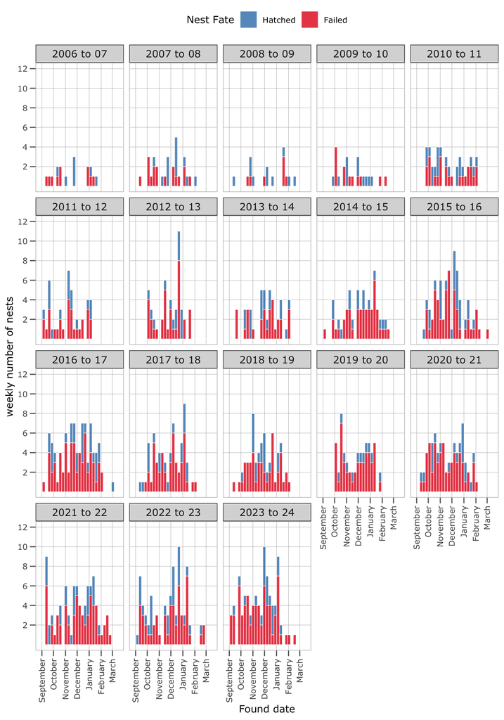

```r
ggplot(nest_data_MP_check, aes(first_found2_trans, fill = Fate)) +
  geom_histogram(bins = 30,
                 alpha = 0.8, color = "white", linewidth = 0.2) +
  scale_fill_manual(values = c("1" = brewer.pal(8, "Set1")[c(1)], "0" = brewer.pal(8, "Set1")[c(2)]),
                    name = "Nest Fate",
                    labels = c("Hatched", "Failed")) +
  ylab("weekly number of nests") +
  scale_x_date(date_labels = "%B",
               # expand = c(0.01, 0.01),
               date_breaks = "1 months", limits = c(min(nest_data_MP_check$first_found2_trans, na.rm = TRUE),
                                                    max(nest_data_MP_check$last_checked2_trans, na.rm = TRUE))) +
  facet_wrap("season_label") +
  scale_y_continuous(limits = c(0, 12), breaks = c(2, 4, 6, 8, 10, 12)) +
  luke_theme +
  xlab("Found date") +
  theme(legend.position = "top",
        panel.grid.major = element_line(colour = "grey70",
                                        size = 0.15),
        axis.text.x = element_text(angle = 90, hjust = 1, vjust = 0.5))
```

##### Year-specific Last Alive Date Distributions

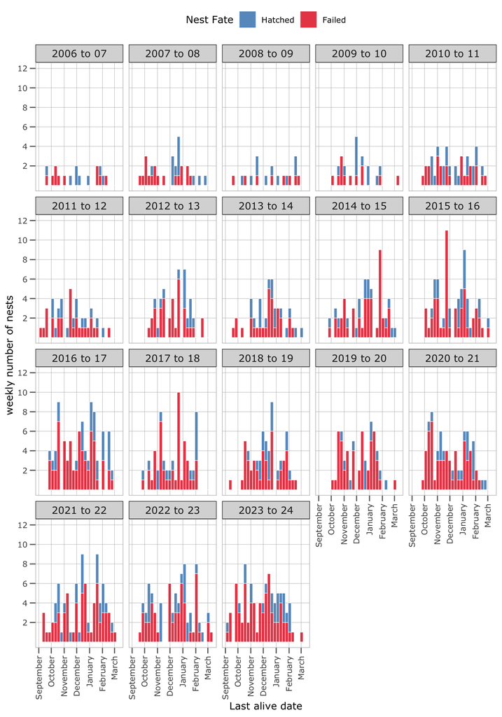

```r
ggplot(nest_data_MP_check, aes(last_alive2_trans, fill = as.factor(Fate))) +
  geom_histogram(bins = 30,
                 alpha = 0.8, color = "white", linewidth = 0.2) +
  scale_fill_manual(values = c("1" = brewer.pal(8, "Set1")[c(1)], "0" = brewer.pal(8, "Set1")[c(2)]),
                    name = "Nest Fate",
                    labels = c("Hatched", "Failed")) +
  ylab("weekly number of nests") +
  scale_x_date(date_labels = "%B",
               expand = c(0.01, 0.01),
               date_breaks = "1 months", limits = c(min(nest_data_MP_check$first_found2_trans, na.rm = TRUE),
                                                    max(nest_data_MP_check$last_checked2_trans, na.rm = TRUE))) +
  facet_wrap("season_label") +
  scale_y_continuous(limits = c(0, 12), breaks = c(2, 4, 6, 8, 10, 12)) +
  luke_theme +
  xlab("Last alive date") +
  theme(legend.position = "top",
        panel.grid.major = element_line(colour = "grey70",
                                        size = 0.15),
        axis.text.x = element_text(angle = 90, hjust = 1, vjust = 0.5))
```

##### Year-specific Last Checked Date Distributions

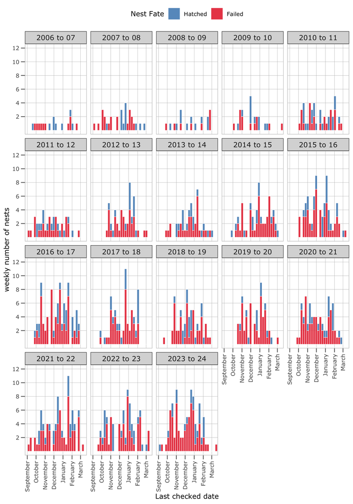

```r
ggplot(nest_data_MP_check, aes(last_checked2_trans, fill = as.factor(Fate))) +
  geom_histogram(bins = 30,
                 alpha = 0.8, color = "white", linewidth = 0.2) +
  scale_fill_manual(values = c("1" = brewer.pal(8, "Set1")[c(1)], "0" = brewer.pal(8, "Set1")[c(2)]),
                    name = "Nest Fate",
                    labels = c("Hatched", "Failed")) +
  ylab("weekly number of nests") +
  scale_x_date(date_labels = "%B",
               expand = c(0.01, 0.01),
               date_breaks = "1 months", limits = c(min(nest_data_MP_check$first_found2_trans, na.rm = TRUE),
                                                    max(nest_data_MP_check$last_checked2_trans, na.rm = TRUE))) +
  facet_wrap("season_label") +
  scale_y_continuous(limits = c(0, 12), breaks = c(2, 4, 6, 8, 10, 12)) +
  luke_theme +
  xlab("Last checked date") +
  theme(legend.position = "top",
        panel.grid.major = element_line(colour = "grey70",
                                        size = 0.15),
        axis.text.x = element_text(angle = 90, hjust = 1, vjust = 0.5))
```

##### Tally number of nests per year in the dataset

```r
nest_data_MP_check %>%
  group_by(season) %>%
  summarise(n())
```

```
# A tibble: 18 × 2
   season `n()`
   <fct>  <int>
 1 200607    18
 2 200708    31
 3 200809    18
 4 200910    23
 5 201011    45
 6 201112    43
 7 201213    48
 8 201314    46
 9 201415    61
10 201516    76
11 201617    93
12 201718    65
13 201819    64
14 201920    61
15 202021    78
16 202122    88
17 202223    81
18 202324    92
```

```r
# Total number of nests acorss all years
nest_data_MP_check %>%
  summarise(n())
```

```
# A tibble: 1 × 1
  `n()`
  <int>
1  1031
```

##### Incubation length distribution

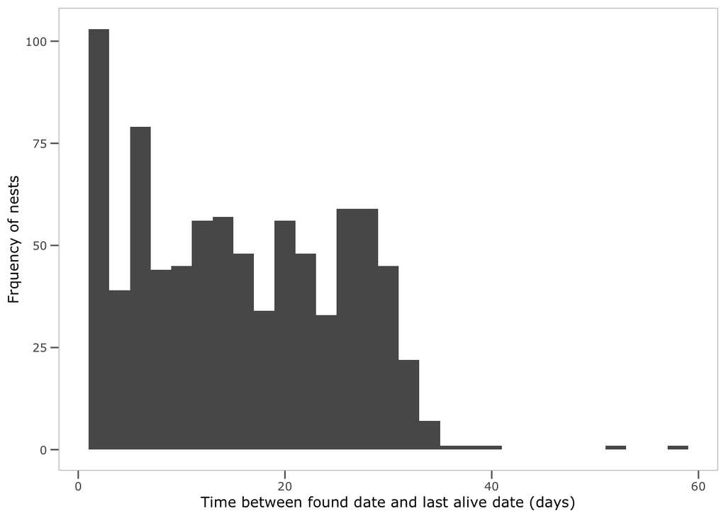

```r
# assess if there are nests with unusually long incubation periods
nest_data_MP_check %>%
  mutate(found_and_alive_diff = last_alive2 - first_found2) %>%
  arrange(desc(found_and_alive_diff)) %>%
  filter(first_found2 < last_alive2 & first_found2 < last_checked2 & found_and_alive_diff < 100) %>%
  ggplot() +
  geom_histogram(aes(found_and_alive_diff)) +
  luke_theme +
  xlab("Time between found date and last alive date (days)") +
  ylab("Frquency of nests")
```

[output not shown]

[output not shown]

[output not shown]

[output not shown]

[output not shown]

### Fleurieu Peninsula

#### Flag potential issues in data

```r
FP_nest_data_issues <-
suppressMessages(
  bind_rows(
  read_excel(paste0("data/", "FP Nesting summary_All years_30062025.xlsx"),
             sheet = paste0("FP", " ", "2023", "_", str_sub("2024", 3, 4)),
             col_types = "text", na = "n/a"),
  read_excel(paste0("data/", "FP Nesting summary_All years_30062025.xlsx"),
             sheet = paste0("FP", " ", "2022", "_", str_sub("2023", 3, 4)),
             col_types = "text", na = "n/a"),
  read_excel(paste0("data/", "FP Nesting summary_All years_30062025.xlsx"),
             sheet = paste0("FP", " ", "2021", "_", str_sub("2022", 3, 4)),
             col_types = "text", na = "n/a"),
  read_excel(paste0("data/", "FP Nesting summary_All years_30062025.xlsx"),
             sheet = paste0("FP", " ", "2020", "_", str_sub("2021", 3, 4)),
             col_types = "text", na = "n/a"),
  read_excel(paste0("data/", "FP Nesting summary_All years_30062025.xlsx"),
             sheet = paste0("FP", " ", "2019", "_", str_sub("2020", 3, 4)),
             col_types = "text", na = "n/a"),
  read_excel(paste0("data/", "FP Nesting summary_All years_30062025.xlsx"),
             sheet = paste0("FP", " ", "2018", "_", str_sub("2019", 3, 4)),
             col_types = "text", na = "n/a"),
  read_excel(paste0("data/", "FP Nesting summary_All years_30062025.xlsx"),
             sheet = paste0("FP", " ", "2017", "_", str_sub("2018", 3, 4)),
             col_types = "text", na = "n/a"),
  read_excel(paste0("data/", "FP Nesting summary_All years_30062025.xlsx"),
             sheet = paste0("FP", " ", "2016", "_", str_sub("2017", 3, 4)),
             col_types = "text", na = "n/a"),
  read_excel(paste0("data/", "FP Nesting summary_All years_30062025.xlsx"),
             sheet = paste0("FP", " ", "2015", "_", str_sub("2016", 3, 4)),
             col_types = "text", na = "n/a"),
  read_excel(paste0("data/", "FP Nesting summary_All years_30062025.xlsx"),
             sheet = paste0("FP", " ", "2014", "_", str_sub("2015", 3, 4)),
             col_types = "text", na = "n/a"),
  read_excel(paste0("data/", "FP Nesting summary_All years_30062025.xlsx"),
             sheet = paste0("FP", " ", "2013", "_", str_sub("2014", 3, 4)),
             col_types = "text", na = "n/a"),
  read_excel(paste0("data/", "FP Nesting summary_All years_30062025.xlsx"),
             sheet = paste0("FP", " ", "2012", "_", str_sub("2013", 3, 4)),
             col_types = "text", na = "n/a"),
  read_excel(paste0("data/", "FP Nesting summary_All years_30062025.xlsx"),
             sheet = paste0("FP", " ", "2011", "_", str_sub("2012", 3, 4)),
             col_types = "text", na = "n/a"),
  read_excel(paste0("data/", "FP Nesting summary_All years_30062025.xlsx"),
             sheet = paste0("FP", " ", "2010", "_", str_sub("2011", 3, 4)),
             col_types = "text", na = "n/a"),
  read_excel(paste0("data/", "FP Nesting summary_All years_30062025.xlsx"),
             sheet = paste0("FP", " ", "2009", "_", str_sub("2010", 3, 4)),
             col_types = "text", na = "n/a"))) %>%
    filter(!is.na(Season)) %>%
  rename(first_found = 13,
         last_alive = 33,
         last_checked = 39,
         Fate = `Hatch?`,
         season = Season,
         # site = Site,
         site = `Suggested update to site name`,
         nest_ID = `Nest ID`,
         nest_hab = `Nest habitat`,
         management_status = `Nest managed?`,
         management_type = `Management type`,
         nest_lat = `Nest latitude`,
         nest_lon = `Nest longitude`,
         state_1st_ob = `Age stage first observed`) %>%
  rename(
    chick_1st_ob = !!names(.)[which(names(.) %in% c("Date chicks sighted", "Chicks first obsv date"))][1],
    clutch_comp  = !!names(.)[which(names(.) %in% c("Known clutch complete date", "Known laying date"))][1]
  ) %>%
  # chick_1st_ob = which(names(.) %in% c("Date chicks sighted", "Chicks first obsv date"))[1],
  # clutch_comp = which(names(.) %in% c("Known clutch complete date", "Known laying date"))) %>%
  dplyr::select(season, site, nest_ID, first_found, last_alive, last_checked, Fate, nest_hab,
                management_status, management_type, nest_lat, nest_lon, site,
                chick_1st_ob, clutch_comp, state_1st_ob) %>%
  mutate(Fate = ifelse(Fate == "?", "Unk", Fate)) %>%
  mutate(Fate = toupper(Fate)) %>%
  filter(
    is.na(first_found) |
      grepl("^\\s*-?\\d+(\\.\\d+)?\\s*$", first_found)
  ) %>%
  mutate(last_checked = ifelse(!is.na(last_checked) & !grepl("^\\s*-?\\d+(\\.\\d+)?\\s*$", last_checked),
                               NA, last_checked)) %>%
  mutate(last_alive = ifelse(!is.na(last_alive) & !grepl("^\\s*-?\\d+(\\.\\d+)?\\s*$", last_alive),
                             NA, last_alive)) %>%
  mutate(last_alive = ifelse(str_detect(last_alive, "Unk."), NA, last_alive),
         Fate = ifelse(Fate == "Y", 0,
                       ifelse(Fate == "N", 1,
                              ifelse(Fate == "UNK", NA, "XXX")))) %>%
  # remove nests without Fate information
  filter(Fate %in% c("0", "1")) %>%
  mutate(chick_1st_ob = case_when(
    # Excel serial dates stored as numbers
    str_detect(chick_1st_ob, "^[0-9]+$") ~ as.Date(as.numeric(chick_1st_ob), origin = "1899-12-30"),

    # Dates with extra text in parentheses — extract only the date part
    str_detect(chick_1st_ob, "^\\d{1,2}/\\d{1,2}/\\d{2,4}") ~ suppressWarnings(
      dmy(str_extract(chick_1st_ob, "^\\d{1,2}/\\d{1,2}/\\d{2,4}"))
    ),

    # Everything else (including "Unk", "Failed during laying") → NA
    TRUE ~ as.Date(NA)
  ),
  clutch_comp =  case_when(
    # Excel serial dates stored as numbers
    str_detect(clutch_comp, "^[0-9]+$") ~ as.Date(as.numeric(clutch_comp), origin = "1899-12-30"),

    # Dates with extra text in parentheses — extract only the date part
    str_detect(clutch_comp, "^\\d{1,2}/\\d{1,2}/\\d{2,4}") ~ suppressWarnings(
      dmy(str_extract(clutch_comp, "^\\d{1,2}/\\d{1,2}/\\d{2,4}"))
    ),

    # Everything else (including "Unk", "Failed during laying") → NA
    TRUE ~ as.Date(NA)
  )) %>%
  # if the clutch completion date is NA, then estimate it as 35 days before estimated hatch date
  # using the date of first chick observation and the size of the chicks when seen
  mutate(clutch_comp = ifelse(!is.na(clutch_comp), clutch_comp,
                              ifelse(Fate == 0 & is.na(clutch_comp) & !is.na(chick_1st_ob) & !is.na(state_1st_ob),
                                     ifelse(state_1st_ob == "1/3 adult size, fluffy", chick_1st_ob - 3 - 35,
                                            ifelse(state_1st_ob == "1/2 adult size, fluffy", chick_1st_ob - 10 - 35,
                                                   ifelse(state_1st_ob == "2/3 adult size, fluffy", chick_1st_ob - 19 - 35,
                                                          ifelse(state_1st_ob == "Adult size, mottled grey", chick_1st_ob - 30 - 35,
                                                                 ifelse(state_1st_ob == "Fledged", chick_1st_ob - 35 - 35,
                                                                        ifelse(state_1st_ob == "wet in nest", chick_1st_ob - 35, NA)))))),
                                     ifelse(Fate == 0 & is.na(clutch_comp) & !is.na(chick_1st_ob) & is.na(state_1st_ob), NA, NA))) %>% as.Date()) %>%
  mutate(last_alive2 = ifelse(Fate == 0 & !is.na(clutch_comp) & is.na(last_alive), clutch_comp + 35,
                              ifelse(Fate == 0 & is.na(clutch_comp) & !is.na(chick_1st_ob) & !is.na(state_1st_ob) & is.na(last_alive),
                                     ifelse(state_1st_ob == "1/3 adult size, fluffy", chick_1st_ob - 3,
                                            ifelse(state_1st_ob == "1/2 adult size, fluffy", chick_1st_ob - 10,
                                                   ifelse(state_1st_ob == "2/3 adult size, fluffy", chick_1st_ob - 19,
                                                          ifelse(state_1st_ob == "Adult size, mottled grey", chick_1st_ob - 30,
                                                                 ifelse(state_1st_ob == "Fledged", chick_1st_ob - 35,
                                                                        ifelse(state_1st_ob == "wet in nest", chick_1st_ob, NA)))))),
                                     ifelse(Fate == 0 & is.na(clutch_comp) & !is.na(chick_1st_ob) & is.na(state_1st_ob) & is.na(last_alive), NA, NA))) %>% as.Date()) %>%
  # mutate(last_alive2 = ifelse(Fate == 0 & !is.na(chick_1st_ob) & last_alive2 > chick_1st_ob, chick_1st_ob, last_alive2) %>% as.Date()) %>%
  mutate(last_alive = ifelse(!is.na(last_alive2),
                             paste0(str_sub(as.character(last_alive2), 9, 10),
                                    str_sub(as.character(last_alive2), 6, 7),
                                    str_sub(as.character(last_alive2), 1, 4)), last_alive)) %>%
  mutate(
    last_checked = ifelse(!is.na(last_alive) & is.na(last_checked),
                          last_alive,
                          ifelse(is.na(last_alive) & is.na(last_checked),
                                 first_found, last_checked))) %>%
  mutate(
    last_alive = ifelse(is.na(last_alive) & Fate == "0" & !is.na(last_checked),
                        last_checked,
                        ifelse(is.na(last_alive) & Fate == "1" & !is.na(last_checked),
                               first_found,
                               last_alive))) %>%
  filter(
    (is.na(last_alive) | nchar(last_alive) == 8) &
      (is.na(first_found) | nchar(first_found) == 8) &
      (is.na(last_checked) | nchar(last_checked) == 8)
  ) %>%
  mutate(first_found2 = as.Date(paste(str_sub(first_found, 5, 8),
                                      str_sub(first_found, 3, 4),
                                      str_sub(first_found, 1, 2), sep = "-")),
         last_alive2 = as.Date(paste(str_sub(last_alive, 5, 8),
                                     str_sub(last_alive, 3, 4),
                                     str_sub(last_alive, 1, 2), sep = "-")),
         last_checked2 = as.Date(paste(str_sub(last_checked, 5, 8),
                                       str_sub(last_checked, 3, 4),
                                       str_sub(last_checked, 1, 2), sep = "-"))) %>%
  mutate(last_checked2 = ifelse(!is.na(last_alive2) & !is.na(last_checked2) & last_checked2 < last_alive2,
                                last_alive2, last_checked2) %>% as.Date()) %>%
  mutate(first_found2 = ifelse(!is.na(clutch_comp) & ((last_alive2 - first_found2) > 40 | (last_alive2 - first_found2) < 0)
                               & ((last_alive2 - clutch_comp) < 40 | (last_alive2 - clutch_comp) > 0),
                               clutch_comp, first_found2) %>% as.Date()) %>%
  mutate(FirstFound = as.numeric(format(first_found2 + 180, "%j")),
         LastPresent = as.numeric(format(last_alive2 + 180, "%j")),
         LastChecked = as.numeric(format(last_checked2 + 180, "%j"))) %>%
  # mutate(FirstFound = ((as.integer(format(first_found2, "%j")) -
  #                         as.integer(format(as.Date("2001-06-01"), "%j")) + 1) %% 365) %>%
  #          replace(. == 0, 365),#as.numeric(format(first_found2 + 180, "%j")),
  #        LastPresent = ((as.integer(format(last_alive2, "%j")) -
  #                          as.integer(format(as.Date("2001-06-01"), "%j")) + 1) %% 365) %>%
  #          replace(. == 0, 365),#as.numeric(format(last_alive2 + 180, "%j")),
  #        LastChecked = ((as.integer(format(last_checked2, "%j")) -
  #                          as.integer(format(as.Date("2001-06-01"), "%j")) + 1) %% 365) %>%
  #          replace(. == 0, 365)) %>% #as.numeric(format(last_checked2 + 180, "%j"))) %>%
  mutate(management_type = tolower(management_type)) %>%
  mutate(nest_hab = tolower(nest_hab)) %>%
  mutate(management_type = str_replace(management_type, "acess", "access")) %>%
  mutate(management_type = str_replace(management_type, "and", ",")) %>%
  mutate(management_type = str_replace(management_type, "temporary", "")) %>%
  mutate(management_type = str_replace_all(management_type, " ", "")) %>%
```

```r
  mutate(management_type = str_replace_all(management_type, "shelters", "")) %>%
  mutate(management_type = str_replace_all(management_type, "banners", "")) %>%
  mutate(management_type = str_replace_all(management_type, ",,", ",")) %>%
  mutate(sign_access = ifelse(str_detect(management_type, "signaccess"), 1, 0)) %>%
  mutate(sign_nest = ifelse(str_detect(management_type, "signnest"), 1, 0)) %>%
  mutate(rope_fence = ifelse(str_detect(management_type, "ropefence"), 1, 0)) %>%
  mutate(perm_fence = ifelse(str_detect(management_type, "permanentfence"), 1, 0)) %>% # & nest_hab == "dune", 1, 0)) %>%
  mutate(wardens = ifelse(str_detect(management_type, "wardens"), 1, 0)) %>%
  mutate(none = ifelse(str_detect(management_type, "none"), 1,
                       ifelse(is.na(management_type) & management_status == "N", 1, 0))) %>%
  mutate(other = ifelse(str_detect(management_type, "other"), 1, 0)) %>%
  mutate(management_level = ifelse((sign_access == 1 | perm_fence == 1) & sign_nest == 1 & rope_fence == 1 & wardens == 1, 4,
                                   ifelse(rope_fence == 1, 3,
                                          ifelse(sign_nest == 1, 2,
                                                 ifelse(sign_access == 1 | perm_fence == 1, 1,
                                                        ifelse(none == 1, 0, NA)))))) %>%
  mutate(sign_nest_no_sign_access = ifelse(sign_access == 0 & sign_nest == 1, 1, 0)) %>%
  mutate(fence_no_sign = ifelse((sign_access == 0 & sign_nest == 0) & rope_fence == 1, 1, 0)) %>%
  mutate(wardens_no_sign = ifelse((sign_access == 0 & sign_nest == 0) & wardens == 1, 1, 0)) %>%
  mutate(wardens_no_fence = ifelse(rope_fence == 1 & wardens == 1, 1, 0)) %>%
  mutate(just_wardens = ifelse(rope_fence == 0 & sign_access == 0 & sign_nest == 0 & wardens == 1, 1, 0)) %>%
  dplyr::select(-other, -sign_nest_no_sign_access, -fence_no_sign,
                -wardens_no_sign, -wardens_no_fence, -just_wardens) %>%
  group_by(season) %>%
  mutate(nocc = max(max(LastChecked, na.rm = TRUE), max(LastPresent, na.rm = TRUE)),
         season = as.factor(season),
         nest_hab = as.factor(nest_hab),
         management_status = as.factor(management_status)) %>%
  mutate(region = "MP") %>%
  mutate(site = as.factor(site)) %>%
  mutate(issue1 = ifelse(nchar(first_found) != 8, "found date is not 8 characters; ", NA)) %>%
  mutate(issue2 = ifelse(nchar(last_alive) != 8, "last seen alive date is not 8 characters; ", NA)) %>%
  mutate(issue3 = ifelse(nchar(last_checked) != 8, "last checked date is not 8 characters; ", NA)) %>%
  mutate(issue4 = ifelse(is.na(first_found), "found date missing; ", NA)) %>%
  mutate(issue5 = ifelse(is.na(last_alive), "last seen alive date missing; ", NA)) %>%
  mutate(issue6 = ifelse(is.na(last_checked), "last checked date missing; ", NA)) %>%
  mutate(issue7 = ifelse(management_status %!in% c("Y", "N"), "Nest managed? is not Y or N; ", NA)) %>%
  mutate(issue8 = ifelse(nest_hab %!in% c("beach", "dune", "foredune/face", "estuary/spit", "rocks"),
                         "Nest habitat is not beach, dune, foredune/face, estuary/spit, or rocks; ", NA)) %>%
  mutate(issue9 = ifelse(is.na(management_level), "Management type is not sufficient for making levels; ", NA)) %>%
  mutate(found_and_alive_diff = last_alive2 - first_found2) %>%
  mutate(issue10 = ifelse(found_and_alive_diff > 40 , "Double check dates because incubation time greater than 40 days; ", NA)) %>%
  mutate(issue11 = ifelse(first_found2 > last_alive2, "Found date is after Last Alive date (should be greater or equal); ", NA)) %>%
  mutate(issue12 = ifelse(first_found2 > last_checked2, "Found date is after Last Checked date (should be greater or equal); ", NA)) %>%
  mutate(issue13 = ifelse(last_checked2 < last_alive2, "Last Checked date is before Last Alive date (should be greater or equal); ", NA)) %>%
  mutate(issues = ifelse(is.na(issue1) & is.na(issue2) & is.na(issue3) &
                           is.na(issue4) & is.na(issue5) & is.na(issue6) &
                           is.na(issue7) & is.na(issue8) & is.na(issue9) &
                           is.na(issue10) & is.na(issue11) & is.na(issue12) & is.na(issue13), NA,
                         paste0(issue1, issue2, issue3,
                                issue4, issue5, issue6,
                                issue7, issue8, issue9,
                                issue10, issue11, issue12, issue13))) %>%
  mutate(issues = str_remove_all(issues, "NA")) %>%
  mutate(issues = ifelse(is.na(issues), "usable", issues)) %>%
  dplyr::select(-issue1, -issue2, -issue3,
                -issue4, -issue5, -issue6,
                -issue7, -issue8, -issue9,
                -issue10, -issue11, -issue12, -issue13) %>%
  filter(issues != "usable") %>%
  arrange(issues)
```

#### all issues (probably most of these can’t be resolved)

```r
# Create a new workbook to store issues as two sheets
FP_nest_issues <- createWorkbook()

# Add all_issues sheet
addWorksheet(FP_nest_issues, "all_issues")

# view issues interactively in RStudio Viewer
FP_nest_data_issues %>%
  datatable(class = 'cell-border stripe', rownames = FALSE, filter = 'top')
```

| season | site | nest_ID | first_found | last_alive | last_checked | Fate | nest_hab | management_status | management_type | nest_lat | nest_lon | chick_1st_ob | clutch_comp | state_1st_ob | last_alive2 | first_found2 | last_checked2 | FirstFound | LastPresent | LastChecked | sign_access | sign_nest | rope_fence | perm_fence | wardens | none | management_level | nocc | region | … |
| --- | --- | --- | --- | --- | --- | --- | --- | --- | --- | --- | --- | --- | --- | --- | --- | --- | --- | --- | --- | --- | --- | --- | --- | --- | --- | --- | --- | --- | --- | --- |
| 202122 | Aldinga | 202122_Aldinga/Aldinga Nth (Aldinga Beach Rd)_2 | 06112021 | 17122021 | 18122021 | 1 | beach | Y | signaccess,signnest,ropefence,dogsonleash200m/new'nostop'signs/breedingchart | -35.290905000000002 | 138.44511199999999 |  |  |  | 2021-12-17 | 2021-11-06 | 2021-12-18 | 125 | 166 | 167 | 1 | 1 | 1 | 0 | 0 | 0 | 3 | 226 | MP | … |
| 202021 | Henley Beach | 202021_Henley Beach_1 | 06092020 | 18102020 | 20102020 | 1 | foredune/face | Y | signaccess,signnest,ropefence |  |  |  |  |  | 2020-10-18 | 2020-09-06 | 2020-10-20 | 64 | 106 | 108 | 1 | 1 | 1 | 0 | 0 | 0 | 3 | 243 | MP | … |
| 201920 | Maslin Beach | 201920_Maslin Beach_3 | 12122019 | 22012020 | 23012020 | 1 | beach | Y | signaccess,signnest,ropefence |  |  |  |  |  | 2020-01-22 | 2019-12-12 | 2020-01-23 | 161 | 202 | 203 | 1 | 1 | 1 | 0 | 0 | 0 | 3 | 225 | MP | … |
| 201516 | Shelley Beach (lady bay) | 201516_Shelley Beach (lady bay)_1 | 15122015 | 04022016 | 08022016 | 1 | beach | Y | signnest,ropefence | -35.48227 | 138.27471 |  |  |  | 2016-02-04 | 2015-12-15 | 2016-02-08 | 164 | 215 | 219 | 0 | 1 | 1 | 0 | 0 | 0 | 3 | 231 | MP | … |
| 202223 | Aldinga | 202223_Aldinga/Aldinga Nth (Aldinga Beach Rd)_2 | 06102022 | 06102022 | 06102022 | 1 | beach | N |  |  |  |  |  |  | 2022-10-06 | 2022-10-06 | 2022-10-06 | 94 | 94 | 94 |  |  |  |  |  |  |  | 256 | MP | … |
| 202223 | Ballaparudda | 202223_Ballaparudda/Callawonga_1 | 24112022 | 24112022 | 05122022 | 1 | beach | N |  | -35.637664000000001 | 138.40130400000001 |  |  |  | 2022-11-24 | 2022-11-24 | 2022-12-05 | 143 | 143 | 154 |  |  |  |  |  |  |  | 256 | MP | … |
| 202223 | Callawonga | 202223_Ballaparudda/Callawonga_2 | 06012023 | 06012023 | 24012023 | 1 | beach | N |  | -35.638364000000003 | 138.38797500000001 |  |  |  | 2023-01-06 | 2023-01-06 | 2023-01-24 | 186 | 186 | 204 |  |  |  |  |  |  |  | 256 | MP | … |
| 202223 | Moana Beach South | 202223_Moana Beach South/Moana Beach_2 | 11102022 | 13102022 | 14102022 | 1 | beach | N |  |  |  |  |  |  | 2022-10-13 | 2022-10-11 | 2022-10-14 | 99 | 101 | 102 |  |  |  |  |  |  |  | 256 | MP | … |
| 202223 | Myponga Beach Estuary | 202223_Myponga Beach Estuary_1 | 05112022 | 06112022 | 07112022 | 1 | estuary/spit | N |  | -35.37303 | 138.38531 |  |  |  | 2022-11-06 | 2022-11-05 | 2022-11-07 | 124 | 125 | 126 |  |  |  |  |  |  |  | 256 | MP | … |
| 202223 | Ochre Cove, Maslins | 202223_Ochre Cove, Maslins_5 | 19102022 | 20102022 | 21102022 | 1 | foredune/face | N |  | -35.226011999999997 | 138.469401 |  |  |  | 2022-10-20 | 2022-10-19 | 2022-10-21 | 107 | 108 | 109 |  |  |  |  |  |  |  | 256 | MP | … |

[output cut: 26 more lines]

```r
# write FP_nest_data_check
writeData(FP_nest_issues, sheet = "all_issues", FP_nest_data_issues)
```

#### date-specific issues (probably most of these CAN be resolved)

```r
# Add date_issues
addWorksheet(FP_nest_issues, "date_issues")

# there are some blank (but non-NA) observations of management_type
FP_nest_data_issues %>% filter(is.na(management_type))
```

```
# A tibble: 18 × 32
# Groups:   season [1]
   season site        nest_ID first_found last_alive last_checked Fate  nest_hab
   <fct>  <fct>       <chr>   <chr>       <chr>      <chr>        <chr> <fct>
 1 202223 Aldinga     202223… 06102022    06102022   06102022     1     beach
 2 202223 Ballaparud… 202223… 24112022    24112022   05122022     1     beach
 3 202223 Callawonga  202223… 06012023    06012023   24012023     1     beach
 4 202223 Moana Beac… 202223… 11102022    13102022   14102022     1     beach
 5 202223 Myponga Be… 202223… 05112022    06112022   07112022     1     estuary…
 6 202223 Ochre Cove… 202223… 19102022    20102022   21102022     1     foredun…
 7 202223 Parsons Be… 202223… 09122022    09122022   11122022     1     beach
 8 202223 Port Willu… 202223… 13092022    14092022   17092022     1     beach
 9 202223 Tunkalilla… 202223… 01102022    01102022   09102022     1     beach
10 202223 Tunkalilla… 202223… 09012023    09012023   29012023     1     beach
11 202223 Tunkalilla… 202223… 29012023    29012023   07022023     1     beach
12 202223 Tunkalilla… 202223… 07112022    17112022   30112022     1     foredun…
13 202223 Tunkalilla… 202223… 17112022    17112022   30112022     1     dune
14 202223 Tunkalilla… 202223… 17112022    17112022   30112022     1     foredun…
15 202223 Waitpinga … 202223… 26102022    26102022   05112022     1     beach
16 202223 Waitpinga … 202223… 05112022    05112022   22112022     1     beach
17 202223 Yankalilla… 202223… 01092022    02092022   02092022     1     beach
18 202223 Yankalilla… 202223… 30092022    30092022   30092022     1     estuary…
# ℹ 24 more variables: management_status <fct>, management_type <chr>,
#   nest_lat <chr>, nest_lon <chr>, chick_1st_ob <date>, clutch_comp <date>,
#   state_1st_ob <chr>, last_alive2 <date>, first_found2 <date>,
#   last_checked2 <date>, FirstFound <dbl>, LastPresent <dbl>,
#   LastChecked <dbl>, sign_access <dbl>, sign_nest <dbl>, rope_fence <dbl>,
#   perm_fence <dbl>, wardens <dbl>, none <dbl>, management_level <dbl>,
#   nocc <dbl>, region <chr>, found_and_alive_diff <drtn>, issues <chr>
```

```r
# view issues interactively in RStudio Viewer
FP_nest_data_issues %>%
  filter(first_found != "Not found" & last_alive != "Not seen" & last_checked != "Not seen" & last_checked != "Not revisited") %>%
  filter(str_detect(issues, "date")) %>%
  mutate(issues = str_remove_all(issues, "Management type is not sufficient for making levels; ")) %>%
  mutate(issues = str_remove_all(issues, "Nest habitat is not beach, dune, foredune/face, estuary/spit, or rocks; ")) %>%
  dplyr::select(season, nest_ID, nest_hab, first_found, first_found2, last_alive, last_alive2, last_checked, last_checked2,
                Fate, found_and_alive_diff, issues)  %>%
  datatable(class = 'cell-border stripe', rownames = FALSE, filter = 'top')
```

| season | nest_ID | nest_hab | first_found | first_found2 | last_alive | last_alive2 | last_checked | last_checked2 | Fate | found_and_alive_diff | issues |
| --- | --- | --- | --- | --- | --- | --- | --- | --- | --- | --- | --- |
| 202122 | 202122_Aldinga/Aldinga Nth (Aldinga Beach Rd)_2 | beach | 06112021 | 2021-11-06 | 17122021 | 2021-12-17 | 18122021 | 2021-12-18 | 1 | 41 | Double check dates because incubation time greater than 40 days; |
| 202021 | 202021_Henley Beach_1 | foredune/face | 06092020 | 2020-09-06 | 18102020 | 2020-10-18 | 20102020 | 2020-10-20 | 1 | 42 | Double check dates because incubation time greater than 40 days; |
| 201920 | 201920_Maslin Beach_3 | beach | 12122019 | 2019-12-12 | 22012020 | 2020-01-22 | 23012020 | 2020-01-23 | 1 | 41 | Double check dates because incubation time greater than 40 days; |
| 201516 | 201516_Shelley Beach (lady bay)_1 | beach | 15122015 | 2015-12-15 | 04022016 | 2016-02-04 | 08022016 | 2016-02-08 | 1 | 51 | Double check dates because incubation time greater than 40 days; |

```r
# write FP_nest_data_check
FP_nest_data_issues %>%
  filter(first_found != "Not found" & last_alive != "Not seen" & last_checked != "Not seen" & last_checked != "Not revisited") %>%
  filter(str_detect(issues, "date")) %>%
  mutate(issues = str_remove_all(issues, "Management type is not sufficient for making levels; ")) %>%
  mutate(issues = str_remove_all(issues, "Nest habitat is not Beach, Dune, Foredune/face, Estuary/spit, or Rocks; ")) %>%
  dplyr::select(season, nest_ID, first_found, first_found2, last_alive, last_alive2, last_checked, last_checked2,
                Fate, found_and_alive_diff, issues) %>%
  writeData(FP_nest_issues, sheet = "date_issues", .)

# Save the workbook
saveWorkbook(FP_nest_issues, here("data/nest_issues_commented/FP_nest_data_issues_220825.xlsx"), overwrite = TRUE)
```

#### Import data

```r
nest_data_FP <-
  bind_rows(
    nest_import(year_1 = "2023", year_2 = "2024",
                        file_name = "FP Nesting summary_All years_30062025.xlsx", site = "FP",
                        first_found_date_col = 13,
                        last_alive_date_col = 33,
                        last_checked_col = 39),
    nest_import(year_1 = "2022", year_2 = "2023",
                        file_name = "FP Nesting summary_All years_30062025.xlsx", site = "FP",
                        first_found_date_col = 13,
                        last_alive_date_col = 33,
                        last_checked_col = 39),
    nest_import(year_1 = "2021", year_2 = "2022",
                        file_name = "FP Nesting summary_All years_30062025.xlsx", site = "FP",
                        first_found_date_col = 13,
                        last_alive_date_col = 33,
                        last_checked_col = 39),
    nest_import(year_1 = "2020", year_2 = "2021",
                        file_name = "FP Nesting summary_All years_30062025.xlsx", site = "FP",
                        first_found_date_col = 12,
                        last_alive_date_col = 33,
                        last_checked_col = 40),
    nest_import(year_1 = "2019", year_2 = "2020",
                        file_name = "FP Nesting summary_All years_30062025.xlsx", site = "FP",
                        first_found_date_col = 12,
                        last_alive_date_col = 33,
                        last_checked_col = 40),
    nest_import(year_1 = "2018", year_2 = "2019",
                        file_name = "FP Nesting summary_All years_30062025.xlsx", site = "FP",
                        first_found_date_col = 12,
                        last_alive_date_col = 33,
                        last_checked_col = 40),
    nest_import(year_1 = "2017", year_2 = "2018",
                        file_name = "FP Nesting summary_All years_30062025.xlsx", site = "FP",
                        first_found_date_col = 12,
                        last_alive_date_col = 33,
                        last_checked_col = 40),
    nest_import(year_1 = "2016", year_2 = "2017",
                        file_name = "FP Nesting summary_All years_30062025.xlsx", site = "FP",
                        first_found_date_col = 12,
                        last_alive_date_col = 33,
                        last_checked_col = 40),
    nest_import(year_1 = "2015", year_2 = "2016",
                        file_name = "FP Nesting summary_All years_30062025.xlsx", site = "FP",
                        first_found_date_col = 12,
                        last_alive_date_col = 33,
                        last_checked_col = 40),
    nest_import(year_1 = "2014", year_2 = "2015",
                        file_name = "FP Nesting summary_All years_30062025.xlsx", site = "FP",
                        first_found_date_col = 12,
                        last_alive_date_col = 33,
                        last_checked_col = 40),
    nest_import(year_1 = "2013", year_2 = "2014",
                        file_name = "FP Nesting summary_All years_30062025.xlsx", site = "FP",
                        first_found_date_col = 12,
                        last_alive_date_col = 33,
                        last_checked_col = 40),
    nest_import(year_1 = "2012", year_2 = "2013",
                        file_name = "FP Nesting summary_All years_30062025.xlsx", site = "FP",
                        first_found_date_col = 12,
                        last_alive_date_col = 33,
                        last_checked_col = 40),
    nest_import(year_1 = "2011", year_2 = "2012",
                        file_name = "FP Nesting summary_All years_30062025.xlsx", site = "FP",
                        first_found_date_col = 12,
                        last_alive_date_col = 33,
                        last_checked_col = 40),
    nest_import(year_1 = "2010", year_2 = "2011",
                        file_name = "FP Nesting summary_All years_30062025.xlsx", site = "FP",
                        first_found_date_col = 12,
                        last_alive_date_col = 33,
                        last_checked_col = 40),
    nest_import(year_1 = "2009", year_2 = "2010",
                        file_name = "FP Nesting summary_All years_30062025.xlsx", site = "FP",
                        first_found_date_col = 12,
                        last_alive_date_col = 33,
                        last_checked_col = 40)) %>%
  group_by(season) %>%
  mutate(nocc = max(max(LastChecked, na.rm = TRUE), max(LastPresent, na.rm = TRUE)),
         season = as.factor(season),
         nest_hab = as.factor(nest_hab),
         management_status = as.factor(management_status)) %>%
  filter(!is.na(FirstFound) & !is.na(LastPresent) & !is.na(LastChecked)) %>%
  filter(management_status %in% c("Y", "N")) %>%
  filter(nest_hab %in% c("beach", "dune", "foredune/face", "estuary/spit", "rocks")) %>%
  filter(!is.na(management_level)) %>% # drops 20 nests
  mutate(region = "FP") %>%
  mutate(site = as.factor(site)) %>%
  group_by(season, site) %>%
  arrange(first_found2, .by_group = TRUE) %>%
  mutate(rank = row_number()) %>%
  ungroup() %>%
  mutate(nest_ID_new = paste(season, site, rank, sep = "_")) %>%
  ungroup()
```

#### Visual inspections of data

```r
nest_data_FP_check <-
  nest_data_FP %>%
  ungroup() %>%
  mutate(first_found2_md = paste(format(first_found2 + 180, format = "%m"),
                                 format(first_found2 + 180, format = "%d"),
                                 sep = "-"),
         last_alive2_md = paste(format(last_alive2 + 180, format = "%m"),
                                format(last_alive2 + 180, format = "%d"),
                                sep = "-"),
         last_checked2_md = paste(format(last_checked2 + 180, format = "%m"),
                                  format(last_checked2 + 180, format = "%d"),
                                  sep = "-")) %>%
  mutate(first_found2_trans = as.Date(paste("2020", first_found2_md, sep = "-"), format = "%Y-%m-%d") - 179,
         last_alive2_trans = as.Date(paste("2020", last_alive2_md, sep = "-"), format = "%Y-%m-%d") - 179,
         last_checked2_trans = as.Date(paste("2020", last_checked2_md, sep = "-"), format = "%Y-%m-%d") - 179) %>%
  mutate(season_label = paste0("season ", str_sub(season, 1, 4), " to ", str_sub(season, 5, 6)))
```

##### Spatial distribution of data

Note that this map only shows data that are in a decimal degrees format (e.g., `-38.31`), NOT degree minute seconds (e.g., `38 27.59`). The map is interactive, so click on an outlier to see its metadata

```r
nest_data_FP_sf <-
  nest_data_FP %>%
  as.data.frame() %>%
  mutate(nest_lon = as.numeric(nest_lon),
         nest_lat = as.numeric(nest_lat)) %>%
  filter(!is.na(nest_lon) & !is.na(nest_lat)) %>%
  st_as_sf(coords = c("nest_lon", "nest_lat"),
           crs = 4326) %>% suppressWarnings()

mapview(nest_data_FP_sf,
        zcol = "season",
        popup = popupTable(nest_data_FP_sf,
                           zcol = c("season",
                                    "site",
                                    "nest_ID")))
```

[interactive chart not shown]

##### Year-specific Found Date Distributions

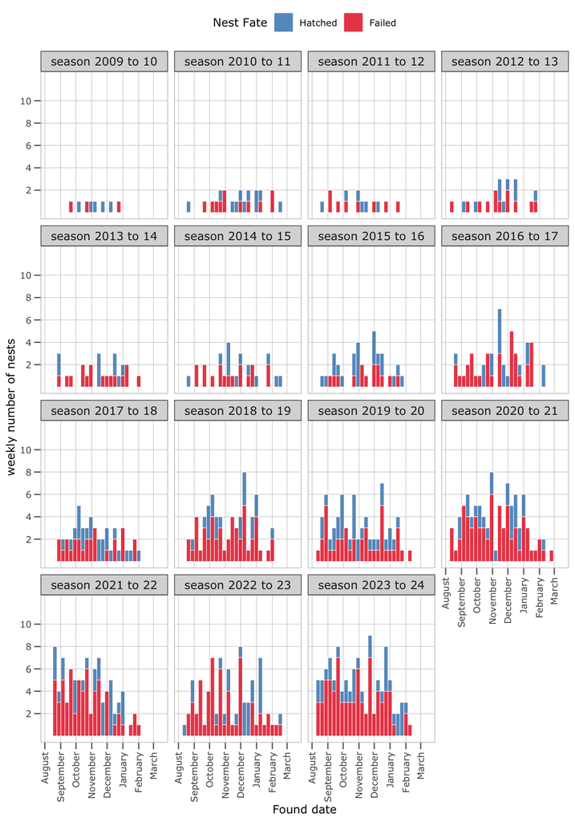

```r
ggplot(nest_data_FP_check, aes(first_found2_trans, fill = Fate)) +
  geom_histogram(bins = 30,
                 alpha = 0.8, color = "white", linewidth = 0.2) +
  scale_fill_manual(values = c("1" = brewer.pal(8, "Set1")[c(1)], "0" = brewer.pal(8, "Set1")[c(2)]),
                    name = "Nest Fate",
                    labels = c("Hatched", "Failed")) +
  ylab("weekly number of nests") +
  scale_x_date(date_labels = "%B",
               # expand = c(0.01, 0.01),
               date_breaks = "1 months", limits = c(min(nest_data_FP_check$first_found2_trans, na.rm = TRUE),
                                                    max(nest_data_FP_check$last_checked2_trans, na.rm = TRUE))) +
  facet_wrap("season_label") +
  scale_y_continuous(limits = c(0, 12), breaks = c(2, 4, 6, 8, 10)) +
  luke_theme +
  xlab("Found date") +
  theme(legend.position = "top",
        panel.grid.major = element_line(colour = "grey70",
                                        size = 0.15),
        axis.text.x = element_text(angle = 90, hjust = 1, vjust = 0.5))
```

##### Year-specific Last Alive Date Distributions

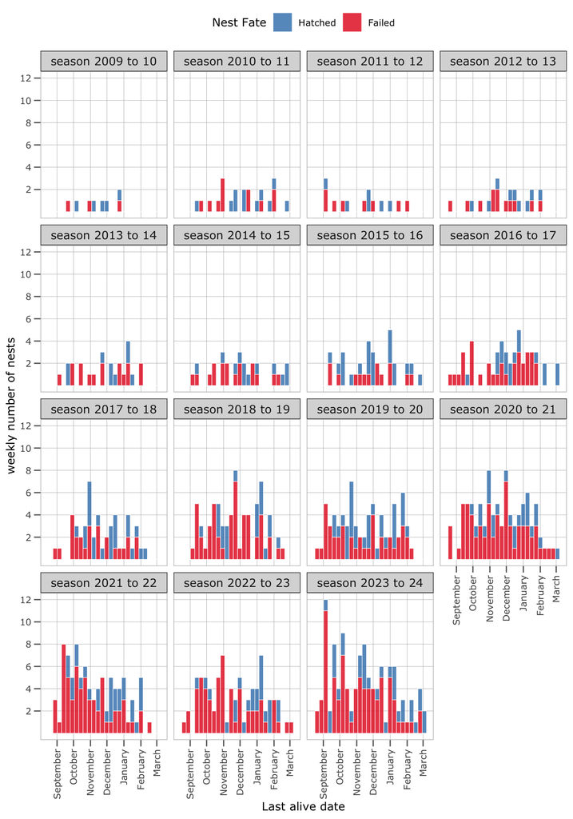

```r
ggplot(nest_data_FP_check, aes(last_alive2_trans, fill = as.factor(Fate))) +
  geom_histogram(bins = 30,
                 alpha = 0.8, color = "white", linewidth = 0.2) +
  scale_fill_manual(values = c("1" = brewer.pal(8, "Set1")[c(1)], "0" = brewer.pal(8, "Set1")[c(2)]),
                    name = "Nest Fate",
                    labels = c("Hatched", "Failed")) +
  ylab("weekly number of nests") +
  scale_x_date(date_labels = "%B",
               expand = c(0.01, 0.01),
               date_breaks = "1 months", limits = c(min(nest_data_FP_check$first_found2_trans, na.rm = TRUE),
                                                    max(nest_data_FP_check$last_checked2_trans, na.rm = TRUE))) +
  facet_wrap("season_label") +
  scale_y_continuous(limits = c(0, 12), breaks = c(2, 4, 6, 8, 10, 12)) +
  luke_theme +
  xlab("Last alive date") +
  theme(legend.position = "top",
        panel.grid.major = element_line(colour = "grey70",
                                        size = 0.15),
        axis.text.x = element_text(angle = 90, hjust = 1, vjust = 0.5))
```

##### Year-specific Last Checked Date Distributions

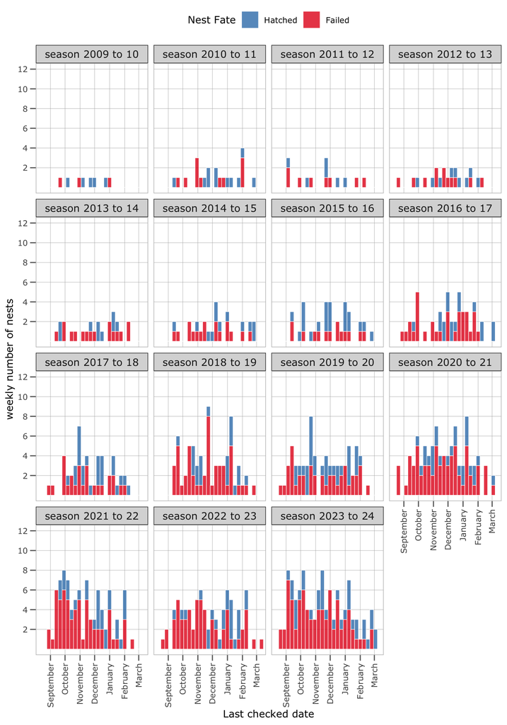

```r
ggplot(nest_data_FP_check, aes(last_checked2_trans, fill = as.factor(Fate))) +
  geom_histogram(bins = 30,
                 alpha = 0.8, color = "white", linewidth = 0.2) +
  scale_fill_manual(values = c("1" = brewer.pal(8, "Set1")[c(1)], "0" = brewer.pal(8, "Set1")[c(2)]),
                    name = "Nest Fate",
                    labels = c("Hatched", "Failed")) +
  ylab("weekly number of nests") +
  scale_x_date(date_labels = "%B",
               expand = c(0.01, 0.01),
               date_breaks = "1 months", limits = c(min(nest_data_FP_check$first_found2_trans, na.rm = TRUE),
                                                    max(nest_data_FP_check$last_checked2_trans, na.rm = TRUE))) +
  facet_wrap("season_label") +
  scale_y_continuous(limits = c(0, 12), breaks = c(2, 4, 6, 8, 10, 12)) +
  luke_theme +
  xlab("Last checked date") +
  theme(legend.position = "top",
        panel.grid.major = element_line(colour = "grey70",
                                        size = 0.15),
        axis.text.x = element_text(angle = 90, hjust = 1, vjust = 0.5))
```

##### Tally number of nests per year in the dataset

```r
nest_data_FP_check %>%
  group_by(season) %>%
  summarise(n())
```

```
# A tibble: 15 × 2
   season `n()`
   <fct>  <int>
 1 200910     8
 2 201011    22
 3 201112    14
 4 201213    21
 5 201314    25
 6 201415    29
 7 201516    35
 8 201617    50
 9 201718    49
10 201819    70
11 201920    73
12 202021    94
13 202122    90
14 202223    82
15 202324   113
```

```r
nest_data_FP_check %>%
  summarise(n())
```

```
# A tibble: 1 × 1
  `n()`
  <int>
1   775
```

##### Incubation length distribution

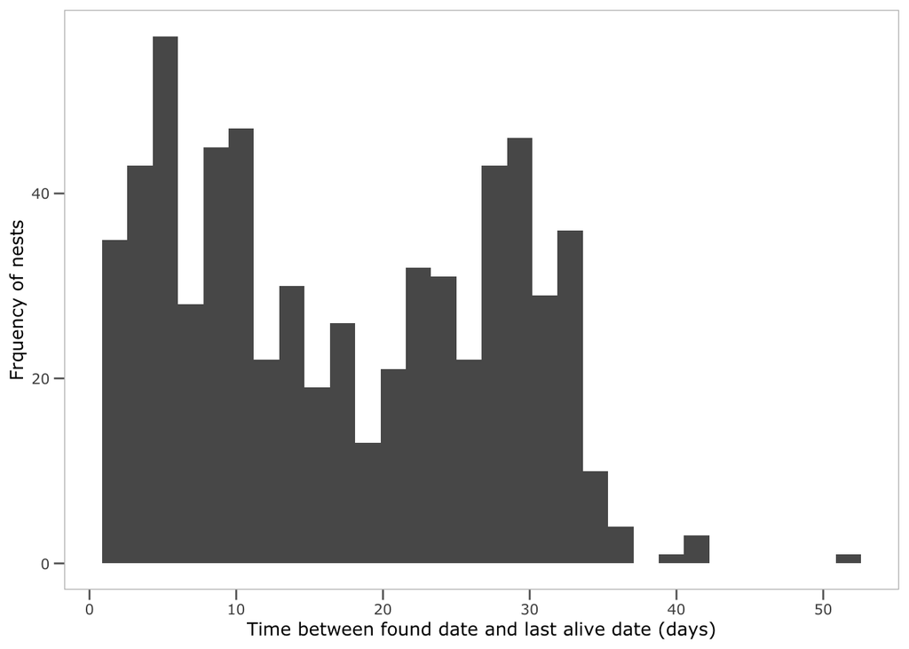

```r
# assess if there are nests with unusually long incubation periods
nest_data_FP_check %>%
  mutate(found_and_alive_diff = last_alive2 - first_found2) %>%
  arrange(desc(found_and_alive_diff)) %>%
  filter(first_found2 < last_alive2 & first_found2 < last_checked2 & found_and_alive_diff < 100) %>%
  ggplot() +
  geom_histogram(aes(found_and_alive_diff)) +
  luke_theme +
  xlab("Time between found date and last alive date (days)") +
  ylab("Frquency of nests")
```

```
# A tibble: 0 × 33
# ℹ 33 variables: season <fct>, site <fct>, nest_ID <chr>, first_found <chr>,
#   last_alive <chr>, last_checked <chr>, Fate <chr>, nest_hab <fct>,
#   management_status <fct>, management_type <chr>, nest_lat <chr>,
#   nest_lon <chr>, chick_1st_ob <date>, clutch_comp <date>,
#   state_1st_ob <chr>, last_alive2 <date>, first_found2 <date>,
#   last_checked2 <date>, FirstFound <dbl>, LastPresent <dbl>,
#   LastChecked <dbl>, sign_access <dbl>, perm_fence <dbl>, sign_nest <dbl>, …
```

```
# A tibble: 0 × 33
# ℹ 33 variables: season <fct>, site <fct>, nest_ID <chr>, first_found <chr>,
#   last_alive <chr>, last_checked <chr>, Fate <chr>, nest_hab <fct>,
#   management_status <fct>, management_type <chr>, nest_lat <chr>,
#   nest_lon <chr>, chick_1st_ob <date>, clutch_comp <date>,
#   state_1st_ob <chr>, last_alive2 <date>, first_found2 <date>,
#   last_checked2 <date>, FirstFound <dbl>, LastPresent <dbl>,
#   LastChecked <dbl>, sign_access <dbl>, perm_fence <dbl>, sign_nest <dbl>, …
```

```
# A tibble: 0 × 33
# ℹ 33 variables: season <fct>, site <fct>, nest_ID <chr>, first_found <chr>,
#   last_alive <chr>, last_checked <chr>, Fate <chr>, nest_hab <fct>,
#   management_status <fct>, management_type <chr>, nest_lat <chr>,
#   nest_lon <chr>, chick_1st_ob <date>, clutch_comp <date>,
#   state_1st_ob <chr>, last_alive2 <date>, first_found2 <date>,
#   last_checked2 <date>, FirstFound <dbl>, LastPresent <dbl>,
#   LastChecked <dbl>, sign_access <dbl>, perm_fence <dbl>, sign_nest <dbl>, …
```

```
.
Double check dates because incubation time greater than 42 days;
                                                                1
```

```
# A tibble: 1 × 4
  issues                                     season nest_ID found_and_alive_diff
  <chr>                                      <fct>  <chr>   <drtn>
1 "Double check dates because incubation ti… 201516 201516… 51 days
```

### Bellarine / Surf Coast

#### Flag potential issues in data

As above, first we import the data and run a few checks to assess if there are any rows with the issues listed above

```r
BSC_nest_data_issues <-
suppressMessages(
  bind_rows(
  read_excel(paste0("data/", "BSC Nesting Summaries_All years_17062025.xlsx"),
             sheet = paste0("BSC", " ", "2023", "_", str_sub("2024", 3, 4)),
             col_types = "text", na = "n/a"),
  read_excel(paste0("data/", "BSC Nesting Summaries_All years_17062025.xlsx"),
             sheet = paste0("BSC", " ", "2022", "_", str_sub("2023", 3, 4)),
             col_types = "text", na = "n/a"),
  read_excel(paste0("data/", "BSC Nesting Summaries_All years_17062025.xlsx"),
             sheet = paste0("BSC", " ", "2021", "_", str_sub("2022", 3, 4)),
             col_types = "text", na = "n/a"),
  read_excel(paste0("data/", "BSC Nesting Summaries_All years_17062025.xlsx"),
             sheet = paste0("BSC", " ", "2020", "_", str_sub("2021", 3, 4)),
             col_types = "text", na = "n/a"),
  read_excel(paste0("data/", "BSC Nesting Summaries_All years_17062025.xlsx"),
             sheet = paste0("BSC", " ", "2019", "_", str_sub("2020", 3, 4)),
             col_types = "text", na = "n/a"),
  read_excel(paste0("data/", "BSC Nesting Summaries_All years_17062025.xlsx"),
             sheet = paste0("BSC", " ", "2018", "_", str_sub("2019", 3, 4)),
             col_types = "text", na = "n/a"),
  read_excel(paste0("data/", "BSC Nesting Summaries_All years_17062025.xlsx"),
             sheet = paste0("BSC", " ", "2017", "_", str_sub("2018", 3, 4)),
             col_types = "text", na = "n/a"),
  read_excel(paste0("data/", "BSC Nesting Summaries_All years_17062025.xlsx"),
             sheet = paste0("BSC", " ", "2016", "_", str_sub("2017", 3, 4)),
             col_types = "text", na = "n/a"),
  read_excel(paste0("data/", "BSC Nesting Summaries_All years_17062025.xlsx"),
             sheet = paste0("BSC", " ", "2015", "_", str_sub("2016", 3, 4)),
             col_types = "text", na = "n/a"),
  read_excel(paste0("data/", "BSC Nesting Summaries_All years_17062025.xlsx"),
             sheet = paste0("BSC", " ", "2014", "_", str_sub("2015", 3, 4)),
             col_types = "text", na = "n/a"),
  read_excel(paste0("data/", "BSC Nesting Summaries_All years_17062025.xlsx"),
             sheet = paste0("BSC", " ", "2013", "_", str_sub("2014", 3, 4)),
             col_types = "text", na = "n/a"),
  read_excel(paste0("data/", "BSC Nesting Summaries_All years_17062025.xlsx"),
             sheet = paste0("BSC", " ", "2012", "_", str_sub("2013", 3, 4)),
             col_types = "text", na = "n/a"),
  read_excel(paste0("data/", "BSC Nesting Summaries_All years_17062025.xlsx"),
             sheet = paste0("BSC", " ", "2011", "_", str_sub("2012", 3, 4)),
             col_types = "text", na = "n/a"),
  read_excel(paste0("data/", "BSC Nesting Summaries_All years_17062025.xlsx"),
             sheet = paste0("BSC", " ", "2010", "_", str_sub("2011", 3, 4)),
             col_types = "text", na = "n/a"),
  read_excel(paste0("data/", "BSC Nesting Summaries_All years_17062025.xlsx"),
             sheet = paste0("BSC", " ", "2009", "_", str_sub("2010", 3, 4)),
             col_types = "text", na = "n/a"),
  read_excel(paste0("data/", "BSC Nesting Summaries_All years_17062025.xlsx"),
             sheet = paste0("BSC", " ", "2008", "_", str_sub("2009", 3, 4)),
             col_types = "text", na = "n/a"),
  read_excel(paste0("data/", "BSC Nesting Summaries_All years_17062025.xlsx"),
             sheet = paste0("BSC", " ", "2007", "_", str_sub("2008", 3, 4)),
             col_types = "text", na = "n/a"),
  read_excel(paste0("data/", "BSC Nesting Summaries_All years_17062025.xlsx"),
             sheet = paste0("BSC", " ", "2006", "_", str_sub("2007", 3, 4)),
             col_types = "text", na = "n/a"))) %>%
    filter(!is.na(Season)) %>%
  rename(first_found = 13,
         last_alive = 33,
         last_checked = 39,
         Fate = `Hatch?`,
         season = Season,
         # site = Site,
         site = `Suggested update to site name`,
         nest_ID = `Nest ID`,
         nest_hab = `Nest habitat`,
         management_status = `Nest managed?`,
         management_type = `Management type`,
         nest_lat = `Nest latitude`,
         nest_lon = `Nest longitude`,
         state_1st_ob = `Age stage first observed`) %>%
  rename(
    chick_1st_ob = !!names(.)[which(names(.) %in% c("Date chicks sighted", "Chicks first obsv date"))][1],
    clutch_comp  = !!names(.)[which(names(.) %in% c("Known clutch complete date", "Known laying date"))][1]
  ) %>%
  # chick_1st_ob = which(names(.) %in% c("Date chicks sighted", "Chicks first obsv date"))[1],
  # clutch_comp = which(names(.) %in% c("Known clutch complete date", "Known laying date"))) %>%
  dplyr::select(season, site, nest_ID, first_found, last_alive, last_checked, Fate, nest_hab,
                management_status, management_type, nest_lat, nest_lon, site,
                chick_1st_ob, clutch_comp, state_1st_ob) %>%
  mutate(Fate = ifelse(Fate == "?", "Unk", Fate)) %>%
  mutate(Fate = toupper(Fate)) %>%
  filter(
    is.na(first_found) |
      grepl("^\\s*-?\\d+(\\.\\d+)?\\s*$", first_found)
  ) %>%
  mutate(last_checked = ifelse(!is.na(last_checked) & !grepl("^\\s*-?\\d+(\\.\\d+)?\\s*$", last_checked),
                               NA, last_checked)) %>%
  mutate(last_alive = ifelse(!is.na(last_alive) & !grepl("^\\s*-?\\d+(\\.\\d+)?\\s*$", last_alive),
                             NA, last_alive)) %>%
  mutate(last_alive = ifelse(str_detect(last_alive, "Unk."), NA, last_alive),
         Fate = ifelse(Fate == "Y", 0,
                       ifelse(Fate == "N", 1,
                              ifelse(Fate == "UNK", NA, "XXX")))) %>%
  # remove nests without Fate information
  filter(Fate %in% c("0", "1")) %>%
  mutate(chick_1st_ob = case_when(
    # Excel serial dates stored as numbers
    str_detect(chick_1st_ob, "^[0-9]+$") ~ as.Date(as.numeric(chick_1st_ob), origin = "1899-12-30"),

    # Dates with extra text in parentheses — extract only the date part
    str_detect(chick_1st_ob, "^\\d{1,2}/\\d{1,2}/\\d{2,4}") ~ suppressWarnings(
      dmy(str_extract(chick_1st_ob, "^\\d{1,2}/\\d{1,2}/\\d{2,4}"))
    ),
```

```r
    # Everything else (including "Unk", "Failed during laying") → NA
    TRUE ~ as.Date(NA)
  ),
  clutch_comp =  case_when(
    # Excel serial dates stored as numbers
    str_detect(clutch_comp, "^[0-9]+$") ~ as.Date(as.numeric(clutch_comp), origin = "1899-12-30"),

    # Dates with extra text in parentheses — extract only the date part
    str_detect(clutch_comp, "^\\d{1,2}/\\d{1,2}/\\d{2,4}") ~ suppressWarnings(
      dmy(str_extract(clutch_comp, "^\\d{1,2}/\\d{1,2}/\\d{2,4}"))
    ),

    # Everything else (including "Unk", "Failed during laying") → NA
    TRUE ~ as.Date(NA)
  )) %>%
  # if the clutch completion date is NA, then estimate it as 35 days before estimated hatch date
  # using the date of first chick observation and the size of the chicks when seen
  mutate(clutch_comp = ifelse(!is.na(clutch_comp), clutch_comp,
                              ifelse(Fate == 0 & is.na(clutch_comp) & !is.na(chick_1st_ob) & !is.na(state_1st_ob),
                                     ifelse(state_1st_ob == "1/3 adult size, fluffy", chick_1st_ob - 3 - 35,
                                            ifelse(state_1st_ob == "1/2 adult size, fluffy", chick_1st_ob - 10 - 35,
                                                   ifelse(state_1st_ob == "2/3 adult size, fluffy", chick_1st_ob - 19 - 35,
                                                          ifelse(state_1st_ob == "Adult size, mottled grey", chick_1st_ob - 30 - 35,
                                                                 ifelse(state_1st_ob == "Fledged", chick_1st_ob - 35 - 35,
                                                                        ifelse(state_1st_ob == "wet in nest", chick_1st_ob - 35, NA)))))),
                                     ifelse(Fate == 0 & is.na(clutch_comp) & !is.na(chick_1st_ob) & is.na(state_1st_ob), NA, NA))) %>% as.Date()) %>%
  mutate(last_alive2 = ifelse(Fate == 0 & !is.na(clutch_comp) & is.na(last_alive), clutch_comp + 35,
                              ifelse(Fate == 0 & is.na(clutch_comp) & !is.na(chick_1st_ob) & !is.na(state_1st_ob) & is.na(last_alive),
                                     ifelse(state_1st_ob == "1/3 adult size, fluffy", chick_1st_ob - 3,
                                            ifelse(state_1st_ob == "1/2 adult size, fluffy", chick_1st_ob - 10,
                                                   ifelse(state_1st_ob == "2/3 adult size, fluffy", chick_1st_ob - 19,
                                                          ifelse(state_1st_ob == "Adult size, mottled grey", chick_1st_ob - 30,
                                                                 ifelse(state_1st_ob == "Fledged", chick_1st_ob - 35,
                                                                        ifelse(state_1st_ob == "wet in nest", chick_1st_ob, NA)))))),
                                     ifelse(Fate == 0 & is.na(clutch_comp) & !is.na(chick_1st_ob) & is.na(state_1st_ob) & is.na(last_alive), NA, NA))) %>% as.Date()) %>%
  # mutate(last_alive2 = ifelse(Fate == 0 & !is.na(chick_1st_ob) & last_alive2 > chick_1st_ob, chick_1st_ob, last_alive2) %>% as.Date()) %>%
  mutate(last_alive = ifelse(!is.na(last_alive2),
                             paste0(str_sub(as.character(last_alive2), 9, 10),
                                    str_sub(as.character(last_alive2), 6, 7),
                                    str_sub(as.character(last_alive2), 1, 4)), last_alive)) %>%
  mutate(
    last_checked = ifelse(!is.na(last_alive) & is.na(last_checked),
                          last_alive,
                          ifelse(is.na(last_alive) & is.na(last_checked),
                                 first_found, last_checked))) %>%
  mutate(
    last_alive = ifelse(is.na(last_alive) & Fate == "0" & !is.na(last_checked),
                        last_checked,
                        ifelse(is.na(last_alive) & Fate == "1" & !is.na(last_checked),
                               first_found,
                               last_alive))) %>%
  filter(
    (is.na(last_alive) | nchar(last_alive) == 8) &
      (is.na(first_found) | nchar(first_found) == 8) &
      (is.na(last_checked) | nchar(last_checked) == 8)
  ) %>%
  mutate(first_found2 = as.Date(paste(str_sub(first_found, 5, 8),
                                      str_sub(first_found, 3, 4),
                                      str_sub(first_found, 1, 2), sep = "-")),
         last_alive2 = as.Date(paste(str_sub(last_alive, 5, 8),
                                     str_sub(last_alive, 3, 4),
                                     str_sub(last_alive, 1, 2), sep = "-")),
         last_checked2 = as.Date(paste(str_sub(last_checked, 5, 8),
                                       str_sub(last_checked, 3, 4),
                                       str_sub(last_checked, 1, 2), sep = "-"))) %>%
  mutate(last_checked2 = ifelse(!is.na(last_alive2) & !is.na(last_checked2) & last_checked2 < last_alive2,
                                last_alive2, last_checked2) %>% as.Date()) %>%
  mutate(first_found2 = ifelse(!is.na(clutch_comp) & ((last_alive2 - first_found2) > 40 | (last_alive2 - first_found2) < 0)
                               & ((last_alive2 - clutch_comp) < 40 | (last_alive2 - clutch_comp) > 0),
                               clutch_comp, first_found2) %>% as.Date()) %>%
  mutate(FirstFound = as.numeric(format(first_found2 + 180, "%j")),
         LastPresent = as.numeric(format(last_alive2 + 180, "%j")),
         LastChecked = as.numeric(format(last_checked2 + 180, "%j"))) %>%
  # mutate(FirstFound = ((as.integer(format(first_found2, "%j")) -
  #                         as.integer(format(as.Date("2001-06-01"), "%j")) + 1) %% 365) %>%
  #          replace(. == 0, 365),#as.numeric(format(first_found2 + 180, "%j")),
  #        LastPresent = ((as.integer(format(last_alive2, "%j")) -
  #                          as.integer(format(as.Date("2001-06-01"), "%j")) + 1) %% 365) %>%
  #          replace(. == 0, 365),#as.numeric(format(last_alive2 + 180, "%j")),
  #        LastChecked = ((as.integer(format(last_checked2, "%j")) -
  #                          as.integer(format(as.Date("2001-06-01"), "%j")) + 1) %% 365) %>%
  #          replace(. == 0, 365)) %>% #as.numeric(format(last_checked2 + 180, "%j"))) %>%
  mutate(management_type = tolower(management_type)) %>%
  mutate(nest_hab = tolower(nest_hab)) %>%
  mutate(management_type = str_replace(management_type, "acess", "access")) %>%
  mutate(management_type = str_replace(management_type, "and", ",")) %>%
  mutate(management_type = str_replace(management_type, "temporary", "")) %>%
  mutate(management_type = str_replace_all(management_type, " ", "")) %>%
  mutate(management_type = str_replace_all(management_type, "shelters", "")) %>%
  mutate(management_type = str_replace_all(management_type, "banners", "")) %>%
  mutate(management_type = str_replace_all(management_type, ",,", ",")) %>%
  mutate(sign_access = ifelse(str_detect(management_type, "signaccess"), 1, 0)) %>%
  mutate(sign_nest = ifelse(str_detect(management_type, "signnest"), 1, 0)) %>%
  mutate(rope_fence = ifelse(str_detect(management_type, "ropefence"), 1, 0)) %>%
  mutate(perm_fence = ifelse(str_detect(management_type, "permanentfence"), 1, 0)) %>% # & nest_hab == "dune", 1, 0)) %>%
  mutate(wardens = ifelse(str_detect(management_type, "wardens"), 1, 0)) %>%
  mutate(none = ifelse(str_detect(management_type, "none"), 1,
                       ifelse(is.na(management_type) & management_status == "N", 1, 0))) %>%
  mutate(other = ifelse(str_detect(management_type, "other"), 1, 0)) %>%
  mutate(management_level = ifelse((sign_access == 1 | perm_fence == 1) & sign_nest == 1 & rope_fence == 1 & wardens == 1, 4,
                                   ifelse(rope_fence == 1, 3,
                                          ifelse(sign_nest == 1, 2,
                                                 ifelse(sign_access == 1 | perm_fence == 1, 1,
                                                        ifelse(none == 1, 0, NA)))))) %>%
  mutate(sign_nest_no_sign_access = ifelse(sign_access == 0 & sign_nest == 1, 1, 0)) %>%
  mutate(fence_no_sign = ifelse((sign_access == 0 & sign_nest == 0) & rope_fence == 1, 1, 0)) %>%
  mutate(wardens_no_sign = ifelse((sign_access == 0 & sign_nest == 0) & wardens == 1, 1, 0)) %>%
  mutate(wardens_no_fence = ifelse(rope_fence == 1 & wardens == 1, 1, 0)) %>%
  mutate(just_wardens = ifelse(rope_fence == 0 & sign_access == 0 & sign_nest == 0 & wardens == 1, 1, 0)) %>%
  dplyr::select(-other, -sign_nest_no_sign_access, -fence_no_sign,
                -wardens_no_sign, -wardens_no_fence, -just_wardens) %>%
  group_by(season) %>%
  mutate(nocc = max(max(LastChecked, na.rm = TRUE), max(LastPresent, na.rm = TRUE)),
         season = as.factor(season),
         nest_hab = as.factor(nest_hab),
         management_status = as.factor(management_status)) %>%
  mutate(region = "MP") %>%
  mutate(site = as.factor(site)) %>%
  mutate(issue1 = ifelse(nchar(first_found) != 8, "found date is not 8 characters; ", NA)) %>%
  mutate(issue2 = ifelse(nchar(last_alive) != 8, "last seen alive date is not 8 characters; ", NA)) %>%
  mutate(issue3 = ifelse(nchar(last_checked) != 8, "last checked date is not 8 characters; ", NA)) %>%
  mutate(issue4 = ifelse(is.na(first_found), "found date missing; ", NA)) %>%
  mutate(issue5 = ifelse(is.na(last_alive), "last seen alive date missing; ", NA)) %>%
  mutate(issue6 = ifelse(is.na(last_checked), "last checked date missing; ", NA)) %>%
  mutate(issue7 = ifelse(management_status %!in% c("Y", "N"), "Nest managed? is not Y or N; ", NA)) %>%
  mutate(issue8 = ifelse(nest_hab %!in% c("beach", "dune", "foredune/face", "estuary/spit", "rocks"),
                         "Nest habitat is not beach, dune, foredune/face, estuary/spit, or rocks; ", NA)) %>%
  mutate(issue9 = ifelse(is.na(management_level), "Management type is not sufficient for making levels; ", NA)) %>%
  mutate(found_and_alive_diff = last_alive2 - first_found2) %>%
  mutate(issue10 = ifelse(found_and_alive_diff > 40 , "Double check dates because incubation time greater than 40 days; ", NA)) %>%
  mutate(issue11 = ifelse(first_found2 > last_alive2, "Found date is after Last Alive date (should be greater or equal); ", NA)) %>%
  mutate(issue12 = ifelse(first_found2 > last_checked2, "Found date is after Last Checked date (should be greater or equal); ", NA)) %>%
  mutate(issue13 = ifelse(last_checked2 < last_alive2, "Last Checked date is before Last Alive date (should be greater or equal); ", NA)) %>%
  mutate(issues = ifelse(is.na(issue1) & is.na(issue2) & is.na(issue3) &
                           is.na(issue4) & is.na(issue5) & is.na(issue6) &
                           is.na(issue7) & is.na(issue8) & is.na(issue9) &
                           is.na(issue10) & is.na(issue11) & is.na(issue12) & is.na(issue13), NA,
                         paste0(issue1, issue2, issue3,
                                issue4, issue5, issue6,
                                issue7, issue8, issue9,
                                issue10, issue11, issue12, issue13))) %>%
  mutate(issues = str_remove_all(issues, "NA")) %>%
  mutate(issues = ifelse(is.na(issues), "usable", issues)) %>%
  dplyr::select(-issue1, -issue2, -issue3,
                -issue4, -issue5, -issue6,
                -issue7, -issue8, -issue9,
                -issue10, -issue11, -issue12, -issue13) %>%
  filter(issues != "usable") %>%
  arrange(issues)
```

#### all issues (probably most of these can’t be resolved)

```r
# Create a new workbook to store issues as two sheets
BSC_nest_issues <- createWorkbook()

# Add all_issues sheet
addWorksheet(BSC_nest_issues, "all_issues")

# view issues interactively in RStudio Viewer
BSC_nest_data_issues %>%
  datatable(class = 'cell-border stripe', rownames = FALSE, filter = 'top')
```

| season | site | nest_ID | first_found | last_alive | last_checked | Fate | nest_hab | management_status | management_type | nest_lat | nest_lon | chick_1st_ob | clutch_comp | state_1st_ob | last_alive2 | first_found2 | last_checked2 | FirstFound | LastPresent | LastChecked | sign_access | sign_nest | rope_fence | perm_fence | wardens | none | management_level | nocc | region | … |
| --- | --- | --- | --- | --- | --- | --- | --- | --- | --- | --- | --- | --- | --- | --- | --- | --- | --- | --- | --- | --- | --- | --- | --- | --- | --- | --- | --- | --- | --- | --- |
| 202122 | Point Lonsdale West of 4W | 202122_Point Lonsdale 3W - 4W_4 | 06012022 | 23022022 | 23022022 | 0 | foredune/face | Y | , |  |  | 2022-02-26 | 2022-01-19 | 1/3 adult size, fluffy | 2022-02-23 | 2022-01-19 | 2022-02-23 | 199 | 234 | 234 | 0 | 0 | 0 | 0 | 0 | 0 |  | 234 | MP | … |
| 201314 | 8W Ocean Grove | 201314_8W Ocean Grove_1 | 22112013 | 26122013 | 26122013 | 0 | not specified | Y | signaccess,signnest,ropefence |  |  | 2013-12-18 | 2013-11-21 | 1/3 adult size, fluffy | 2013-12-26 | 2013-11-22 | 2013-12-26 | 141 | 175 | 175 | 1 | 1 | 1 | 0 | 0 | 0 | 3 | 244 | MP | … |
| 201011 | 13th Beach 29W-31W | 201011_13th Beach 29W - 31W_1 | 03012011 | 01012011 | 01012011 | 0 | not specified | N | none |  |  | 2011-01-04 | 2010-11-27 | 1/3 adult size, fluffy | 2011-01-01 | 2010-11-27 | 2011-01-01 | 146 | 181 | 181 | 0 | 0 | 0 | 0 | 0 | 1 | 0 | 244 | MP | … |
| 201011 | Pt Roadknight West Beach (96W) | 201011_Point Roadknight West (96W - 98W)_2 | 01102010 | 26102010 | 26102010 | 0 | not specified | Y | signaccess,signnest,ropefence |  |  | 2010-10-29 | 2010-09-21 | 1/3 adult size, fluffy | 2010-10-26 | 2010-10-01 | 2010-10-26 | 89 | 114 | 114 | 1 | 1 | 1 | 0 | 0 | 0 | 3 | 244 | MP | … |

```r
# write BSC_nest_data_check
writeData(BSC_nest_issues, sheet = "all_issues", BSC_nest_data_issues)
```

#### date-specific issues (probably most of these CAN be resolved)

```r
# Add date_issues
addWorksheet(BSC_nest_issues, "date_issues")

# there are some blank (but non-NA) observations of management_type
BSC_nest_data_issues %>% filter(is.na(management_type))
```

```
# A tibble: 0 × 32
# Groups:   season [0]
# ℹ 32 variables: season <fct>, site <fct>, nest_ID <chr>, first_found <chr>,
#   last_alive <chr>, last_checked <chr>, Fate <chr>, nest_hab <fct>,
#   management_status <fct>, management_type <chr>, nest_lat <chr>,
#   nest_lon <chr>, chick_1st_ob <date>, clutch_comp <date>,
#   state_1st_ob <chr>, last_alive2 <date>, first_found2 <date>,
#   last_checked2 <date>, FirstFound <dbl>, LastPresent <dbl>,
#   LastChecked <dbl>, sign_access <dbl>, sign_nest <dbl>, rope_fence <dbl>, …
```

```r
# view issues interactively in RStudio Viewer
BSC_nest_data_issues %>%
  filter(first_found != "Not found" & last_alive != "Not seen" & last_checked != "Not seen" & last_checked != "Not revisited") %>%
  filter(str_detect(issues, "date")) %>%
  mutate(issues = str_remove_all(issues, "Management type is not sufficient for making levels; ")) %>%
  mutate(issues = str_remove_all(issues, "Nest habitat is not beach, dune, foredune/face, estuary/spit, or rocks; ")) %>%
  dplyr::select(season, nest_ID, nest_hab, first_found, first_found2, last_alive, last_alive2, last_checked, last_checked2,
                Fate, found_and_alive_diff, issues)  %>%
  datatable(class = 'cell-border stripe', rownames = FALSE, filter = 'top')
```

| season | nest_ID | nest_hab | first_found | first_found2 | last_alive | last_alive2 | last_checked | last_checked2 | Fate | found_and_alive_diff | issues |
| --- | --- | --- | --- | --- | --- | --- | --- | --- | --- | --- | --- |

```r
# write BSC_nest_data_check
BSC_nest_data_issues %>%
  filter(first_found != "Not found" & last_alive != "Not seen" & last_checked != "Not seen" & last_checked != "Not revisited") %>%
  filter(str_detect(issues, "date")) %>%
  mutate(issues = str_remove_all(issues, "Management type is not sufficient for making levels; ")) %>%
  mutate(issues = str_remove_all(issues, "Nest habitat is not Beach, Dune, Foredune/face, Estuary/spit, or Rocks; ")) %>%
  dplyr::select(season, nest_ID, first_found, first_found2, last_alive, last_alive2, last_checked, last_checked2,
                Fate, found_and_alive_diff, issues) %>%
  writeData(BSC_nest_issues, sheet = "date_issues", .)

# Save the workbook
saveWorkbook(BSC_nest_issues, here("data/nest_issues_commented/BSC_nest_data_issues_220825.xlsx"), overwrite = TRUE)
```

#### Import data

```r
nest_data_BSC <-
  bind_rows(
    nest_import(year_1 = "2023", year_2 = "2024",
                        file_name = "BSC Nesting Summaries_All years_17062025.xlsx", site = "BSC",
                        first_found_date_col = 13,
                        last_alive_date_col = 31,
                        last_checked_col = 37),
    nest_import(year_1 = "2022", year_2 = "2023",
                        file_name = "BSC Nesting Summaries_All years_17062025.xlsx", site = "BSC",
                        first_found_date_col = 13,
                        last_alive_date_col = 32,
                        last_checked_col = 38),
    nest_import(year_1 = "2021", year_2 = "2022",
                        file_name = "BSC Nesting Summaries_All years_17062025.xlsx", site = "BSC",
                        first_found_date_col = 13,
                        last_alive_date_col = 31,
                        last_checked_col = 37),
    nest_import(year_1 = "2020", year_2 = "2021",
                        file_name = "BSC Nesting Summaries_All years_17062025.xlsx", site = "BSC",
                        first_found_date_col = 12,
                        last_alive_date_col = 33,
                        last_checked_col = 40),
    nest_import(year_1 = "2019", year_2 = "2020",
                        file_name = "BSC Nesting Summaries_All years_17062025.xlsx", site = "BSC",
                        first_found_date_col = 12,
                        last_alive_date_col = 33,
                        last_checked_col = 40),
    nest_import(year_1 = "2018", year_2 = "2019",
                        file_name = "BSC Nesting Summaries_All years_17062025.xlsx", site = "BSC",
                        first_found_date_col = 12,
                        last_alive_date_col = 33,
                        last_checked_col = 40),
    nest_import(year_1 = "2017", year_2 = "2018",
                        file_name = "BSC Nesting Summaries_All years_17062025.xlsx", site = "BSC",
                        first_found_date_col = 12,
                        last_alive_date_col = 33,
                        last_checked_col = 40),
    nest_import(year_1 = "2016", year_2 = "2017",
                        file_name = "BSC Nesting Summaries_All years_17062025.xlsx", site = "BSC",
                        first_found_date_col = 12,
                        last_alive_date_col = 33,
                        last_checked_col = 40),
    nest_import(year_1 = "2015", year_2 = "2016",
                        file_name = "BSC Nesting Summaries_All years_17062025.xlsx", site = "BSC",
                        first_found_date_col = 12,
                        last_alive_date_col = 33,
                        last_checked_col = 40),
    nest_import(year_1 = "2014", year_2 = "2015",
                        file_name = "BSC Nesting Summaries_All years_17062025.xlsx", site = "BSC",
                        first_found_date_col = 12,
                        last_alive_date_col = 33,
                        last_checked_col = 40),
    nest_import(year_1 = "2013", year_2 = "2014",
                        file_name = "BSC Nesting Summaries_All years_17062025.xlsx", site = "BSC",
                        first_found_date_col = 12,
                        last_alive_date_col = 33,
                        last_checked_col = 40),
    nest_import(year_1 = "2012", year_2 = "2013",
                        file_name = "BSC Nesting Summaries_All years_17062025.xlsx", site = "BSC",
                        first_found_date_col = 12,
                        last_alive_date_col = 33,
                        last_checked_col = 40),
    nest_import(year_1 = "2011", year_2 = "2012",
                        file_name = "BSC Nesting Summaries_All years_17062025.xlsx", site = "BSC",
                        first_found_date_col = 12,
                        last_alive_date_col = 33,
                        last_checked_col = 40),
    nest_import(year_1 = "2010", year_2 = "2011",
                        file_name = "BSC Nesting Summaries_All years_17062025.xlsx", site = "BSC",
                        first_found_date_col = 12,
                        last_alive_date_col = 33,
                        last_checked_col = 40),
    nest_import(year_1 = "2009", year_2 = "2010",
                        file_name = "BSC Nesting Summaries_All years_17062025.xlsx", site = "BSC",
                        first_found_date_col = 12,
                        last_alive_date_col = 33,
                        last_checked_col = 40),
    nest_import(year_1 = "2008", year_2 = "2009",
                        file_name = "BSC Nesting Summaries_All years_17062025.xlsx", site = "BSC",
                        first_found_date_col = 12,
                        last_alive_date_col = 33,
                        last_checked_col = 40),
    nest_import(year_1 = "2007", year_2 = "2008",
                        file_name = "BSC Nesting Summaries_All years_17062025.xlsx", site = "BSC",
                        first_found_date_col = 12,
                        last_alive_date_col = 33,
                        last_checked_col = 40),
    nest_import(year_1 = "2006", year_2 = "2007",
                        file_name = "BSC Nesting Summaries_All years_17062025.xlsx", site = "BSC",
                        first_found_date_col = 12,
                        last_alive_date_col = 33,
                        last_checked_col = 40)) %>%
  group_by(season) %>%
  mutate(nocc = max(max(LastChecked, na.rm = TRUE), max(LastPresent, na.rm = TRUE)),
         season = as.factor(season),
         nest_hab = as.factor(nest_hab),
         management_status = as.factor(management_status)) %>%
  filter(!is.na(FirstFound) & !is.na(LastPresent) & !is.na(LastChecked)) %>%
  filter(management_status %in% c("Y", "N")) %>%
  filter(nest_hab %in% c("beach", "dune", "foredune/face", "estuary/spit", "rocks")) %>%
  filter(!is.na(management_level)) %>% # drops 5 nests that have permanentfence in beach or foredune habitat OR have only a nondogssign
  mutate(region = "BSC") %>%
  mutate(site = as.factor(site)) %>%
  group_by(season, site) %>%
  arrange(first_found2, .by_group = TRUE) %>%
  mutate(rank = row_number()) %>%
  ungroup() %>%
  mutate(nest_ID_new = paste(season, site, rank, sep = "_")) %>%
  ungroup()
```

#### Visual inspections of data

```r
nest_data_BSC_check <-
  nest_data_BSC %>%
  ungroup() %>%
  mutate(first_found2_md = paste(format(first_found2 + 180, format = "%m"),
                                 format(first_found2 + 180, format = "%d"),
                                 sep = "-"),
         last_alive2_md = paste(format(last_alive2 + 180, format = "%m"),
                                format(last_alive2 + 180, format = "%d"),
                                sep = "-"),
         last_checked2_md = paste(format(last_checked2 + 180, format = "%m"),
                                  format(last_checked2 + 180, format = "%d"),
                                  sep = "-")) %>%
  mutate(first_found2_trans = as.Date(paste("2020", first_found2_md, sep = "-"), format = "%Y-%m-%d") - 179,
         last_alive2_trans = as.Date(paste("2020", last_alive2_md, sep = "-"), format = "%Y-%m-%d") - 179,
         last_checked2_trans = as.Date(paste("2020", last_checked2_md, sep = "-"), format = "%Y-%m-%d") - 179) %>%
  mutate(season_label = paste0("season ", str_sub(season, 1, 4), " to ", str_sub(season, 5, 6)))
```

##### Spatial distribution of data

Note that this map only shows data that are in a decimal degrees format (e.g., `-38.31`), NOT degree minute seconds (e.g., `38 27.59`). The map is interactive, so click on an outlier to see its metadata

```r
nest_data_BSC_sf <-
  nest_data_BSC %>%
  as.data.frame() %>%
  mutate(nest_lon = as.numeric(nest_lon),
         nest_lat = as.numeric(nest_lat)) %>%
  filter(!is.na(nest_lon) & !is.na(nest_lat)) %>%
  st_as_sf(coords = c("nest_lon", "nest_lat"),
           crs = 4326) %>% suppressWarnings()

mapview(nest_data_BSC_sf,
        zcol = "season",
        popup = popupTable(nest_data_BSC_sf,
                           zcol = c("season",
                                    "site",
                                    "nest_ID")))
```

[interactive chart not shown]

##### Year-specific Found Date Distributions

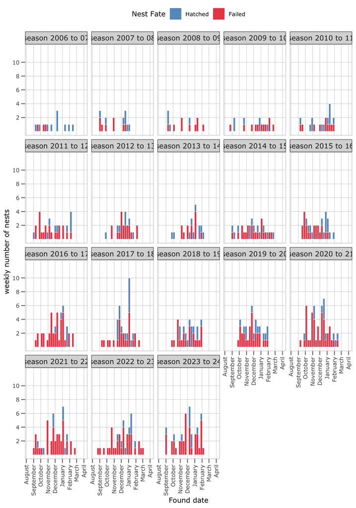

```r
ggplot(nest_data_BSC_check, aes(first_found2_trans, fill = Fate)) +
  geom_histogram(bins = 30,
                 alpha = 0.8, color = "white", linewidth = 0.2) +
  scale_fill_manual(values = c("1" = brewer.pal(8, "Set1")[c(1)], "0" = brewer.pal(8, "Set1")[c(2)]),
                    name = "Nest Fate",
                    labels = c("Hatched", "Failed")) +
  ylab("weekly number of nests") +
  scale_x_date(date_labels = "%B",
               # expand = c(0.01, 0.01),
               date_breaks = "1 months", limits = c(min(nest_data_BSC_check$first_found2_trans, na.rm = TRUE),
                                                    max(nest_data_BSC_check$last_checked2_trans, na.rm = TRUE))) +
  facet_wrap("season_label") +
  scale_y_continuous(limits = c(0, 12), breaks = c(2, 4, 6, 8, 10)) +
  luke_theme +
  xlab("Found date") +
  theme(legend.position = "top",
        panel.grid.major = element_line(colour = "grey70",
                                        size = 0.15),
        axis.text.x = element_text(angle = 90, hjust = 1, vjust = 0.5))
```

##### Year-specific Last Alive Date Distributions

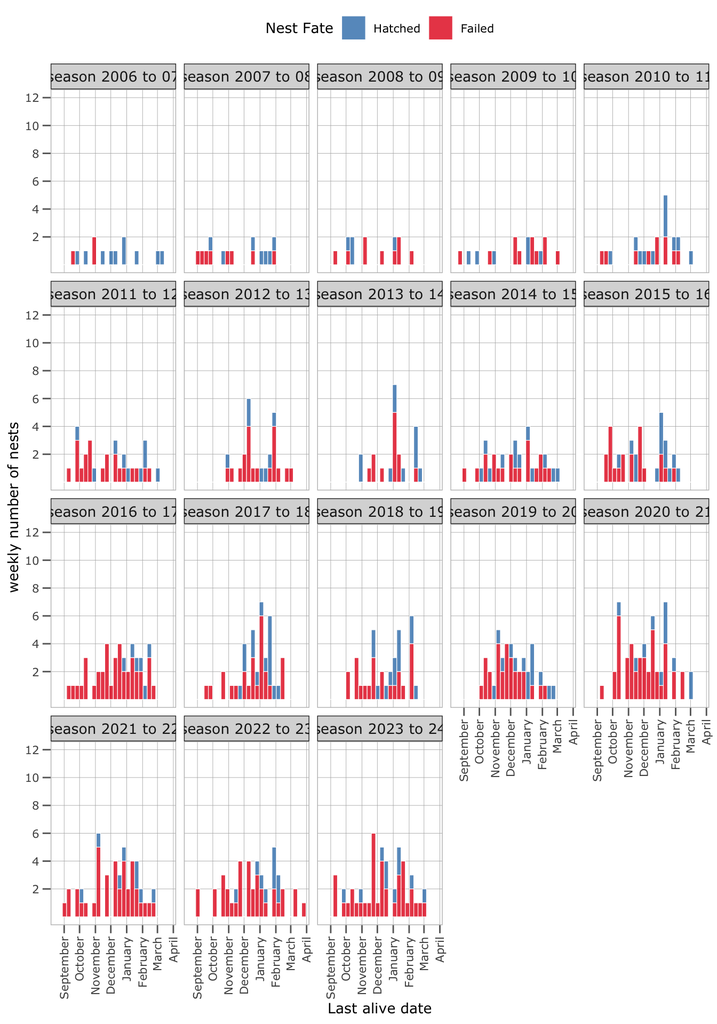

```r
ggplot(nest_data_BSC_check, aes(last_alive2_trans, fill = as.factor(Fate))) +
  geom_histogram(bins = 30,
                 alpha = 0.8, color = "white", linewidth = 0.2) +
  scale_fill_manual(values = c("1" = brewer.pal(8, "Set1")[c(1)], "0" = brewer.pal(8, "Set1")[c(2)]),
                    name = "Nest Fate",
                    labels = c("Hatched", "Failed")) +
  ylab("weekly number of nests") +
  scale_x_date(date_labels = "%B",
               expand = c(0.01, 0.01),
               date_breaks = "1 months", limits = c(min(nest_data_BSC_check$first_found2_trans, na.rm = TRUE),
                                                    max(nest_data_BSC_check$last_checked2_trans, na.rm = TRUE))) +
  facet_wrap("season_label") +
  scale_y_continuous(limits = c(0, 12), breaks = c(2, 4, 6, 8, 10, 12)) +
  luke_theme +
  xlab("Last alive date") +
  theme(legend.position = "top",
        panel.grid.major = element_line(colour = "grey70",
                                        size = 0.15),
        axis.text.x = element_text(angle = 90, hjust = 1, vjust = 0.5))
```

##### Year-specific Last Checked Date Distributions

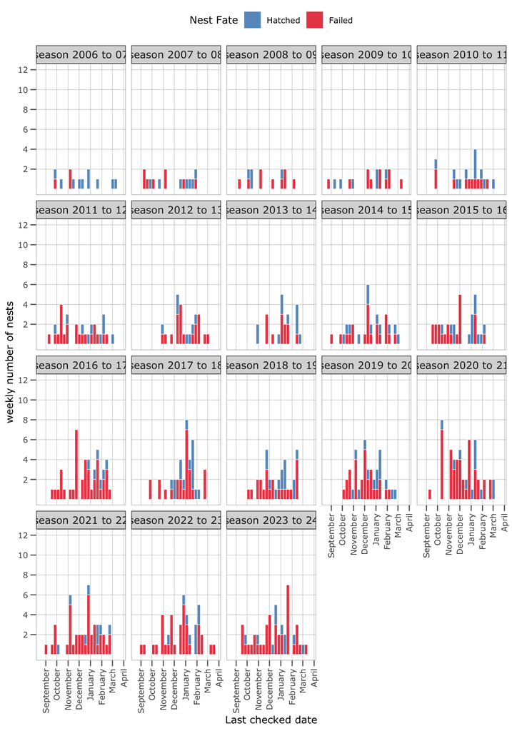

```r
ggplot(nest_data_BSC_check, aes(last_checked2_trans, fill = as.factor(Fate))) +
  geom_histogram(bins = 30,
                 alpha = 0.8, color = "white", linewidth = 0.2) +
  scale_fill_manual(values = c("1" = brewer.pal(8, "Set1")[c(1)], "0" = brewer.pal(8, "Set1")[c(2)]),
                    name = "Nest Fate",
                    labels = c("Hatched", "Failed")) +
  ylab("weekly number of nests") +
  scale_x_date(date_labels = "%B",
               expand = c(0.01, 0.01),
               date_breaks = "1 months", limits = c(min(nest_data_BSC_check$first_found2_trans, na.rm = TRUE),
                                                    max(nest_data_BSC_check$last_checked2_trans, na.rm = TRUE))) +
  facet_wrap("season_label") +
  scale_y_continuous(limits = c(0, 12), breaks = c(2, 4, 6, 8, 10, 12)) +
  luke_theme +
  xlab("Last checked date") +
  theme(legend.position = "top",
        panel.grid.major = element_line(colour = "grey70",
                                        size = 0.15),
        axis.text.x = element_text(angle = 90, hjust = 1, vjust = 0.5))
```

##### Tally number of nests per year in the dataset

```r
nest_data_BSC_check %>%
  group_by(season) %>%
  summarise(n())
```

```
# A tibble: 18 × 2
   season `n()`
   <fct>  <int>
 1 200607    13
 2 200708    15
 3 200809    13
 4 200910    17
 5 201011    21
 6 201112    30
 7 201213    26
 8 201314    22
 9 201415    32
10 201516    34
11 201617    45
12 201718    40
13 201819    35
14 201920    42
15 202021    53
16 202122    46
17 202223    44
18 202324    49
```

```r
nest_data_BSC_check %>%
  summarise(n())
```

```
# A tibble: 1 × 1
  `n()`
  <int>
1   577
```

##### Incubation length distribution

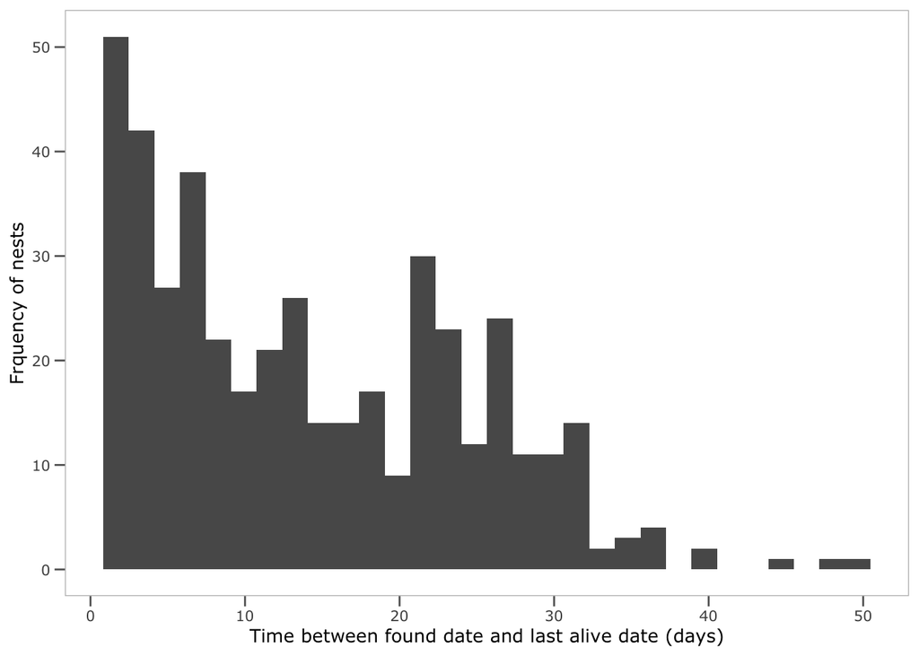

```r
# assess if there are nests with unusually long incubation periods
nest_data_BSC_check %>%
  mutate(found_and_alive_diff = last_alive2 - first_found2) %>%
  arrange(desc(found_and_alive_diff)) %>%
  filter(first_found2 < last_alive2 & first_found2 < last_checked2 & found_and_alive_diff < 100) %>%
  ggplot() +
  geom_histogram(aes(found_and_alive_diff)) +
  luke_theme +
  xlab("Time between found date and last alive date (days)") +
  ylab("Frquency of nests")
```

```
# A tibble: 0 × 33
# ℹ 33 variables: season <fct>, site <fct>, nest_ID <chr>, first_found <chr>,
#   last_alive <chr>, last_checked <chr>, Fate <chr>, nest_hab <fct>,
#   management_status <fct>, management_type <chr>, nest_lat <chr>,
#   nest_lon <chr>, chick_1st_ob <date>, clutch_comp <date>,
#   state_1st_ob <chr>, last_alive2 <date>, first_found2 <date>,
#   last_checked2 <date>, FirstFound <dbl>, LastPresent <dbl>,
#   LastChecked <dbl>, sign_access <dbl>, perm_fence <dbl>, sign_nest <dbl>, …
```

```
# A tibble: 0 × 33
# ℹ 33 variables: season <fct>, site <fct>, nest_ID <chr>, first_found <chr>,
#   last_alive <chr>, last_checked <chr>, Fate <chr>, nest_hab <fct>,
#   management_status <fct>, management_type <chr>, nest_lat <chr>,
#   nest_lon <chr>, chick_1st_ob <date>, clutch_comp <date>,
#   state_1st_ob <chr>, last_alive2 <date>, first_found2 <date>,
#   last_checked2 <date>, FirstFound <dbl>, LastPresent <dbl>,
#   LastChecked <dbl>, sign_access <dbl>, perm_fence <dbl>, sign_nest <dbl>, …
```

```
# A tibble: 1 × 33
  season site         nest_ID first_found last_alive last_checked Fate  nest_hab
  <fct>  <fct>        <chr>   <chr>       <chr>      <chr>        <chr> <fct>
1 202122 Point Lonsd… 202122… 18112021    08112021   20112021     1     beach
# ℹ 25 more variables: management_status <fct>, management_type <chr>,
#   nest_lat <chr>, nest_lon <chr>, chick_1st_ob <date>, clutch_comp <date>,
#   state_1st_ob <chr>, last_alive2 <date>, first_found2 <date>,
#   last_checked2 <date>, FirstFound <dbl>, LastPresent <dbl>,
#   LastChecked <dbl>, sign_access <dbl>, perm_fence <dbl>, sign_nest <dbl>,
#   rope_fence <dbl>, wardens <dbl>, none <dbl>, other <dbl>,
#   management_level <dbl>, nocc <dbl>, region <chr>, rank <int>, …
```

```
.
                                                                     Double check dates because incubation time greater than 41 days;
                                                                                                                                     3
                                                                    Found date is after Last Alive date (should be greater or equal);
                                                                                                                                     3
Found date is after Last Alive date (should be greater or equal); Found date is after Last Checked date (should be greater or equal);
                                                                                                                                     1
```

```
# A tibble: 7 × 3
  issues                                                            season site
  <chr>                                                             <fct>  <fct>
1 "Double check dates because incubation time greater than 41 days… 200708 Poin…
2 "Double check dates because incubation time greater than 41 days… 201213 8W O…
3 "Double check dates because incubation time greater than 41 days… 201617 16W-…
4 "Found date is after Last Alive date (should be greater or equal… 201112 13th…
5 "Found date is after Last Alive date (should be greater or equal… 201213 13th…
6 "Found date is after Last Alive date (should be greater or equal… 202122 Poin…
7 "Found date is after Last Alive date (should be greater or equal… 200708 50W …
```

## Importing and checking threat data

```r
MP_threat_data <-
  read_excel("data/Threat data all years 25062025.xlsx",
             sheet = "MP threats (all years)",
             col_types = "text") %>%
  mutate(season = str_remove(Season, "/")) %>%
  rename(obs_lon = `Observation Longitude`,
         obs_lat = `Observation Latitude`,
         obs_date = `Observation Date`) %>%
  mutate(obs_date = as.Date(as.numeric(obs_date),
                            origin = "1899-12-30")) %>%
  mutate(obs_date2 = as.numeric(format(obs_date + 180, "%j"))) %>%
  mutate(region = "MP")

FP_threat_data <-
  read_excel("data/Threat data all years 25062025.xlsx",
             sheet = "FP threat (all years)",
             col_types = "text") %>%
  mutate(season = str_remove(Season, "/")) %>%
  rename(obs_lon = `Observation Longitude`,
         obs_lat = `Observation Latitude`,
         obs_date = `Observation Date`) %>%
  mutate(obs_date = as.Date(as.numeric(obs_date),
                            origin = "1899-12-30")) %>%
  mutate(obs_date2 = as.numeric(format(obs_date + 180, "%j"))) %>%
  mutate(region = "FP")

BSC_threat_data <-
  read_excel("data/Threat data all years 25062025.xlsx",
             sheet = "BSC threats (all years)",
             col_types = "text") %>%
  mutate(season = str_remove(Season, "/")) %>%
  rename(obs_lon = `Observation Longitude`,
         obs_lat = `Observation Latitude`,
         obs_date = `Observation date`) %>%
  mutate(obs_date = as.Date(as.numeric(obs_date),
                            origin = "1899-12-30")) %>%
  mutate(obs_date2 = as.numeric(format(obs_date + 180, "%j"))) %>%
  mutate(region = "BSC")

threat_data <-
  bind_rows(FP_threat_data, MP_threat_data, BSC_threat_data)
```

```r
threat_data_ <-
  threat_data %>%
  rename(site = `Site name`) %>%
  # first convert all the count columns to numeric
  mutate_at(vars(
    `Walkers/Joggers (wet sand)`,`Walkers/Joggers (dry sand)`,
    `Walkers/Joggers (signs/fence)`,`Walkers/Joggers (Dune)`,`People sunbaking/sitting (wet sand)`,
    `People sunbaking/sitting (dry sand)`,`People sunbaking/sitting (signs/fence)`,
    `People sunbaking/sitting (Dune)`,`Surfers/Swimmers (wet sand)`,
    `Surfers/Swimmers (dry sand)`,`Surfers/Swimmers (signs/fence)`,
    `Surfers/Swimmers (Dune)`,`People Fishing (wet sand)`,
    `People Fishing (dry sand)`,`People Fishing (signs/fence)`,
    `People Fishing (Dune)`,`People Playing Games (wet sand)`,
    `People Playing Games (dry sand)`,`People Playing Games (signs/fence)`,
    `People Playing Games (Dune)`,`Dog Walkers (wet sand)`,
    `Dog Walkers (dry sand)`,`Dog Walkers (signs/fence)`,
    `Dog Walkers (Dune)`,`Dog On Leash (# dogs) (wet sand)`,
    `Dog On Leash (# dogs) (dry sand)`,`Dog On Leash (# dogs) (signs/fence)`,
    `Dog On Leash (# dogs) (Dune)`,`Dog Off Leash (# dogs) (wet sand)`,
    `Dog Off Leash (# dogs) (dry sand)`,`Dog Off Leash (# dogs) (signs/fence)`,
    `Dog Off Leash (# dogs) (Dune)`,`Horses (wet sand)`,
    `Horses (dry sand)`,`Horses (signs/fence)`,
    `Horses (Dune)`,`Permitted vehicle (wet sand)`,
    `Permitted vehicle (dry sand)`,`Permitted vehicle (signs/fence)`,
    `Permitted vehicle (Dune)`,`Illegal vehicle (wet sand)`,
    `Illegal vehicle (dry sand)`,`Illegal vehicle (signs/fence)`,
    `Illegal vehicle (Dune)`,`Ravens (wet sand)`,
    `Ravens (dry sand)`,`Ravens (signs/fence)`,
    `Ravens (Dune)`,`Magpies (wet sand)`,
    `Magpies (dry sand)`,`Magpies (signs/fence)`,
    `Magpies (Dune)`,`Silver Gulls (wet sand)`,
    `Silver Gulls (dry sand)`,`Silver Gulls (signs/fence)`,
    `Silver Gulls (Dune)`,`Pacific/Kelp Gulls (wet sand)`,
    `Pacific/Kelp Gulls (dry sand)`,`Pacific/Kelp Gulls (signs/fence)`,
    `Pacific/Kelp Gulls (Dune)`,`Nankeen Kestrels (wet sand)`,
    `Nankeen Kestrels (dry sand)`,`Nankeen Kestrels (signs/fence)`,
    `Nankeen Kestrels (Dune)`,`Other bird of prey (wet sand)`,
    `Other bird of prey (dry sand)`,`Other bird of prey (signs/fence)`,
    `Other bird of prey (Dune)`,
    `Stock (cattle/sheep) (wet sand)`,
    `Stock (cattle/sheep) (dry sand)`,`Stock (cattle/sheep) (signs/fence)`,
    `Stock (cattle/sheep) (Dune)`), as.numeric) %>%
  ungroup() %>%

  # take the total sum of counts for each threat type (e.g., humans includes
  # Dog Walkers, People Playing Games, People Fishing, Surfers/Swimmers,
  # People sunbaking/sitting, and Walkers/Joggers)
  mutate(humans = rowSums(dplyr::select(.,`Walkers/Joggers (wet sand)`,
                                        `Walkers/Joggers (dry sand)`,
                                        `Walkers/Joggers (signs/fence)`,
                                        `Walkers/Joggers (Dune)`,
                                        `People sunbaking/sitting (wet sand)`,
                                        `People sunbaking/sitting (dry sand)`,
                                        `People sunbaking/sitting (signs/fence)`,
                                        `People sunbaking/sitting (Dune)`,
                                        `Surfers/Swimmers (wet sand)`,
                                        `Surfers/Swimmers (dry sand)`,
                                        `Surfers/Swimmers (signs/fence)`,
                                        `Surfers/Swimmers (Dune)`,
                                        `People Fishing (wet sand)`,
                                        `People Fishing (dry sand)`,
                                        `People Fishing (signs/fence)`,
                                        `People Fishing (Dune)`,
                                        `People Playing Games (wet sand)`,
                                        `People Playing Games (dry sand)`,
                                        `People Playing Games (signs/fence)`,
                                        `People Playing Games (Dune)`,
                                        `Dog Walkers (wet sand)`,
                                        `Dog Walkers (dry sand)`,
                                        `Dog Walkers (signs/fence)`,
                                        `Dog Walkers (Dune)`), na.rm = TRUE),
         # do a micro-habitat specific sum for humans
         humans_wet = rowSums(dplyr::select(.,`Walkers/Joggers (wet sand)`,
                                            `People sunbaking/sitting (wet sand)`,
                                            `Surfers/Swimmers (wet sand)`,
                                            `People Fishing (wet sand)`,
                                            `People Playing Games (wet sand)`,
                                            `Dog Walkers (wet sand)`), na.rm = TRUE),
         humans_dry = rowSums(dplyr::select(.,`Walkers/Joggers (dry sand)`,
                                            `People sunbaking/sitting (dry sand)`,
                                            `Surfers/Swimmers (dry sand)`,
                                            `People Fishing (dry sand)`,
                                            `People Playing Games (dry sand)`,
                                            `Dog Walkers (dry sand)`), na.rm = TRUE),
         humans_dune = rowSums(dplyr::select(.,`Walkers/Joggers (Dune)`,
                                             `People sunbaking/sitting (Dune)`,
                                            `Surfers/Swimmers (Dune)`,
                                            `People Fishing (Dune)`,
                                            `People Playing Games (Dune)`,
                                            `Dog Walkers (Dune)`), na.rm = TRUE),
         humans_SF = rowSums(dplyr::select(.,`Walkers/Joggers (signs/fence)`,
                                            `People sunbaking/sitting (signs/fence)`,
                                            `Surfers/Swimmers (signs/fence)`,
                                            `People Fishing (signs/fence)`,
                                            `People Playing Games (signs/fence)`,
                                            `Dog Walkers (signs/fence)`), na.rm = TRUE),
       dogs = rowSums(dplyr::select(., `Dog On Leash (# dogs) (wet sand)`,
                                    `Dog On Leash (# dogs) (dry sand)`,
                                    `Dog On Leash (# dogs) (signs/fence)`,
                                    `Dog On Leash (# dogs) (Dune)`,
                                    `Dog Off Leash (# dogs) (wet sand)`,
                                    `Dog Off Leash (# dogs) (dry sand)`,
                                    `Dog Off Leash (# dogs) (signs/fence)`,
                                    `Dog Off Leash (# dogs) (Dune)`), na.rm = TRUE),
       # specify a dog on leash and a dog of leash summary
       dogs_on = rowSums(dplyr::select(., `Dog On Leash (# dogs) (wet sand)`,
                                       `Dog On Leash (# dogs) (dry sand)`,
                                       `Dog On Leash (# dogs) (signs/fence)`,
                                       `Dog On Leash (# dogs) (Dune)`), na.rm = TRUE),
       dogs_off = rowSums(dplyr::select(., `Dog Off Leash (# dogs) (wet sand)`,
                                        `Dog Off Leash (# dogs) (dry sand)`,
                                        `Dog Off Leash (# dogs) (signs/fence)`,
                                        `Dog Off Leash (# dogs) (Dune)`), na.rm = TRUE),
       pred_birds = rowSums(dplyr::select(., `Ravens (wet sand)`,
                                          `Ravens (dry sand)`,
                                          `Ravens (signs/fence)`,
                                          `Ravens (Dune)`,
                                          `Magpies (wet sand)`,
                                          `Magpies (dry sand)`,
                                          `Magpies (signs/fence)`,
                                          `Magpies (Dune)`#,
                                          # `Silver Gulls (wet sand)`,
                                          # `Silver Gulls (dry sand)`,
                                          # `Silver Gulls (signs/fence)`,
                                          # `Silver Gulls (Dune)`,
                                          # `Pacific/Kelp Gulls (wet sand)`,
                                          # `Pacific/Kelp Gulls (dry sand)`,
                                          # `Pacific/Kelp Gulls (signs/fence)`,
                                          # `Pacific/Kelp Gulls (Dune)`,
                                          # `Nankeen Kestrels (wet sand)`,
                                          # `Nankeen Kestrels (dry sand)`,
                                          # `Nankeen Kestrels (signs/fence)`,
                                          # `Nankeen Kestrels (Dune)`,
                                          # `Other bird of prey (wet sand)`,
                                          # `Other bird of prey (dry sand)`,
                                          # `Other bird of prey (signs/fence)`,
                                          # `Other bird of prey (Dune)`
                                          ), na.rm = TRUE),
       gulls = rowSums(dplyr::select(., #`Ravens (wet sand)`,
                                          # `Ravens (dry sand)`,
                                          # `Ravens (signs/fence)`,
                                          # `Ravens (Dune)`,
                                          # `Magpies (wet sand)`,
                                          # `Magpies (dry sand)`,
                                          # `Magpies (signs/fence)`,
                                          # `Magpies (Dune)`
                                          `Silver Gulls (wet sand)`,
                                          `Silver Gulls (dry sand)`,
                                          `Silver Gulls (signs/fence)`,
                                          `Silver Gulls (Dune)`,
                                          `Pacific/Kelp Gulls (wet sand)`,
                                          `Pacific/Kelp Gulls (dry sand)`,
                                          `Pacific/Kelp Gulls (signs/fence)`,
                                          `Pacific/Kelp Gulls (Dune)`
                                          # `Nankeen Kestrels (wet sand)`,
                                          # `Nankeen Kestrels (dry sand)`,
                                          # `Nankeen Kestrels (signs/fence)`,
                                          # `Nankeen Kestrels (Dune)`,
                                          # `Other bird of prey (wet sand)`,
                                          # `Other bird of prey (dry sand)`,
                                          # `Other bird of prey (signs/fence)`,
                                          # `Other bird of prey (Dune)`
                                          ), na.rm = TRUE),
       vehicles = rowSums(dplyr::select(., `Permitted vehicle (wet sand)`,
                                        `Permitted vehicle (dry sand)`,
                                        `Permitted vehicle (signs/fence)`,
                                        `Permitted vehicle (Dune)`,
                                        `Illegal vehicle (wet sand)`,
                                        `Illegal vehicle (dry sand)`,
                                        `Illegal vehicle (signs/fence)`,
                                        `Illegal vehicle (Dune)`), na.rm = TRUE),
       hoofed_animals = rowSums(dplyr::select(.,`Horses (wet sand)`,
                                              `Horses (dry sand)`,
                                              `Horses (signs/fence)`,
                                              `Horses (Dune)`,
```

```r
                                              `Stock (cattle/sheep) (wet sand)`,
                                              `Stock (cattle/sheep) (dry sand)`,
                                              `Stock (cattle/sheep) (signs/fence)`,
                                              `Stock (cattle/sheep) (Dune)`), na.rm = TRUE)) %>%
  # consolidate columns names
  rename(hum_pri_wet = `Human Prints (wet sand)`,
         hum_pri_dry = `Human Prints (dry sand)`,
         hum_pri_dune = `Human Prints (Dune)`,
         hum_pri_SF = `Human Prints (signs/fence)`,
         fox_pri_wet = `Fox Prints (wet sand)`,
         fox_pri_dry = `Fox Prints (dry sand)`,
         fox_pri_dune = `Fox Prints (Dune)`,
         fox_pri_SF = `Fox Prints (signs/fence)`,
         dog_pri_wet = `Dog Prints (wet sand)`,
         dog_pri_dry = `Dog Prints (dry sand)`,
         dog_pri_dune = `Dog Prints (Dune)`,
         dog_pri_SF = `Dog Prints (signs/fence)`,
         vehicle_pri_wet = `Vehicle Tracks (wet sand)`,
         vehicle_pri_dry = `Vehicle Tracks (dry sand)`,
         vehicle_pri_dune = `Vehicle Tracks (Dune)`,
         vehicle_pri_SF = `Vehicle Tracks (signs/fence)`,
         trailbike_pri_wet = `Trail bike tracks (wet sand)`,
         trailbike_pri_dry = `Trail bike tracks (dry sand)`,
         trailbike_pri_dune = `Trail bike tracks (Dune)`,
         trailbike_pri_SF = `Trail bike tracks (signs/fence)`,
         stock_pri_wet = `Stock (wet sand)`,
         stock_pri_dry = `Stock (dry sand)`,
         stock_pri_dune = `Stock (Dune)`,
         stock_pri_SF = `Stock (signs/fence)`,
         horse_pri_wet = `Horses Prints (wet sand)`,
         horse_pri_dry = `Horses Prints (dry sand)`,
         horse_pri_dune = `Horses Prints (Dune)`,
         horse_pri_SF = `Horses Prints (signs/fence)`) %>%
  # specify coordinates as numeric
  mutate(obs_lon = as.numeric(obs_lon),
         obs_lat = as.numeric(obs_lat)) %>%
  # clean up factor levels (e.g., sometime "Light", sometimes just "L")
  mutate(hum_pri_wet = ifelse(hum_pri_wet %in% c("Light", "Moderate", "Heavy", "L", "M", "H"),
                              substr(hum_pri_wet, 1, 1),
                              ifelse(hum_pri_wet == "0", "N",
                                     ifelse(hum_pri_wet == "1", "L",
                                           ifelse(hum_pri_wet == "2", "M",
                                                  ifelse(hum_pri_wet == "3", "H",
                                                         ifelse(hum_pri_wet == "high", "H", NA)))))) %>% as.factor(.) %>% factor(., levels = c("L", "M", "H")),
         hum_pri_dry = ifelse(hum_pri_dry %in% c("Light", "Moderate", "Heavy", "L", "M", "H"),
                              substr(hum_pri_dry, 1, 1),
                              ifelse(hum_pri_dry == "0", "N",
                                     ifelse(hum_pri_dry == "1", "L",
                                           ifelse(hum_pri_dry == "2", "M",
                                                  ifelse(hum_pri_dry == "3", "H",
                                                         ifelse(hum_pri_dry == "high", "H", NA)))))) %>% as.factor(.) %>% factor(., levels = c("L", "M", "H")),
         hum_pri_SF =  ifelse(hum_pri_SF %in% c("Light", "Moderate", "Heavy", "L", "M", "H"),
                              substr(hum_pri_SF, 1, 1),
                              ifelse(hum_pri_SF == "0", "N",
                                     ifelse(hum_pri_SF == "1", "L",
                                           ifelse(hum_pri_SF == "2", "M",
                                                  ifelse(hum_pri_SF == "3", "H",
                                                         ifelse(hum_pri_SF == "high", "H", NA)))))) %>% as.factor(.) %>% factor(., levels = c("L", "M", "H")),
         hum_pri_dune = ifelse(hum_pri_dune %in% c("Light", "Moderate", "Heavy", "L", "M", "H"),
                               substr(hum_pri_dune, 1, 1),
                              ifelse(hum_pri_dune == "0", "N",
                                     ifelse(hum_pri_dune == "1", "L",
                                           ifelse(hum_pri_dune == "2", "M",
                                                  ifelse(hum_pri_dune == "3", "H",
                                                         ifelse(hum_pri_dune == "high", "H", NA)))))) %>% as.factor(.) %>% factor(., levels = c("L", "M", "H")),
         fox_pri_wet = ifelse(fox_pri_wet %in% c("Light", "Moderate", "Heavy", "L", "M", "H"),
                              substr(fox_pri_wet, 1, 1),
                              ifelse(fox_pri_wet == "0", "N",
                                     ifelse(fox_pri_wet == "1", "L",
                                           ifelse(fox_pri_wet == "2", "M",
                                                  ifelse(fox_pri_wet == "3", "H",
                                                         ifelse(fox_pri_wet == "high", "H", NA)))))) %>% as.factor(.) %>% factor(., levels = c("L", "M", "H")),
         fox_pri_dry = ifelse(fox_pri_dry %in% c("Light", "Moderate", "Heavy", "L", "M", "H"),
                              substr(fox_pri_dry, 1, 1),
                              ifelse(fox_pri_dry == "0", "N",
                                     ifelse(fox_pri_dry == "1", "L",
                                           ifelse(fox_pri_dry == "2", "M",
                                                  ifelse(fox_pri_dry == "3", "H",
                                                         ifelse(fox_pri_dry == "high", "H", NA)))))) %>% as.factor(.) %>% factor(., levels = c("L", "M", "H")),
         fox_pri_SF = ifelse(fox_pri_SF %in% c("Light", "Moderate", "Heavy", "L", "M", "H"),
                             substr(fox_pri_SF, 1, 1),
                              ifelse(fox_pri_SF == "0", "N",
                                     ifelse(fox_pri_SF == "1", "L",
                                           ifelse(fox_pri_SF == "2", "M",
                                                  ifelse(fox_pri_SF == "3", "H",
                                                         ifelse(fox_pri_SF == "high", "H", NA)))))) %>% as.factor(.) %>% factor(., levels = c("L", "M", "H")),
         fox_pri_dune = ifelse(fox_pri_dune %in% c("Light", "Moderate", "Heavy", "L", "M", "H"),
                               substr(fox_pri_dune, 1, 1),
                              ifelse(fox_pri_dune == "0", "N",
                                     ifelse(fox_pri_dune == "1", "L",
                                           ifelse(fox_pri_dune == "2", "M",
                                                  ifelse(fox_pri_dune == "3", "H",
                                                         ifelse(fox_pri_dune == "high", "H", NA)))))) %>% as.factor(.) %>% factor(., levels = c("L", "M", "H")),
         dog_pri_wet = ifelse(dog_pri_wet %in% c("Light", "Moderate", "Heavy", "L", "M", "H"),
                              substr(dog_pri_wet, 1, 1),
                              ifelse(dog_pri_wet == "0", "N",
                                     ifelse(dog_pri_wet == "1", "L",
                                           ifelse(dog_pri_wet == "2", "M",
                                                  ifelse(dog_pri_wet == "3", "H",
                                                         ifelse(dog_pri_wet == "high", "H", NA)))))) %>% as.factor(.) %>% factor(., levels = c("L", "M", "H")),
         dog_pri_dry = ifelse(dog_pri_dry %in% c("Light", "Moderate", "Heavy", "L", "M", "H"),
                              substr(dog_pri_dry, 1, 1),
                              ifelse(dog_pri_dry == "0", "N",
                                     ifelse(dog_pri_dry == "1", "L",
                                           ifelse(dog_pri_dry == "2", "M",
                                                  ifelse(dog_pri_dry == "3", "H",
                                                         ifelse(dog_pri_dry == "high", "H", NA)))))) %>% as.factor(.) %>% factor(., levels = c("L", "M", "H")),
         dog_pri_SF = ifelse(dog_pri_SF %in% c("Light", "Moderate", "Heavy", "L", "M", "H"),
                             substr(dog_pri_SF, 1, 1),
                              ifelse(dog_pri_SF == "0", "N",
                                     ifelse(dog_pri_SF == "1", "L",
                                           ifelse(dog_pri_SF == "2", "M",
                                                  ifelse(dog_pri_SF == "3", "H",
                                                         ifelse(dog_pri_SF == "high", "H", NA)))))) %>% as.factor(.) %>% factor(., levels = c("L", "M", "H")),
         dog_pri_dune = ifelse(dog_pri_dune %in% c("Light", "Moderate", "Heavy", "L", "M", "H"),
                               substr(dog_pri_dune, 1, 1),
                              ifelse(dog_pri_dune == "0", "N",
                                     ifelse(dog_pri_dune == "1", "L",
                                           ifelse(dog_pri_dune == "2", "M",
                                                  ifelse(dog_pri_dune == "3", "H",
                                                         ifelse(dog_pri_dune == "high", "H", NA)))))) %>% as.factor(.) %>% factor(., levels = c("L", "M", "H")),
         vehicle_pri_wet = ifelse(vehicle_pri_wet %in% c("Light", "Moderate", "Heavy", "L", "M", "H"),
                                  substr(vehicle_pri_wet, 1, 1),
                              ifelse(vehicle_pri_wet == "0", "N",
                                     ifelse(vehicle_pri_wet == "1", "L",
                                           ifelse(vehicle_pri_wet == "2", "M",
                                                  ifelse(vehicle_pri_wet == "3", "H",
                                                         ifelse(vehicle_pri_wet == "high", "H", NA)))))) %>% as.factor(.) %>% factor(., levels = c("L", "M", "H")),
         vehicle_pri_dry = ifelse(vehicle_pri_dry %in% c("Light", "Moderate", "Heavy", "L", "M", "H"),
                                  substr(vehicle_pri_dry, 1, 1),
                              ifelse(vehicle_pri_dry == "0", "N",
                                     ifelse(vehicle_pri_dry == "1", "L",
                                           ifelse(vehicle_pri_dry == "2", "M",
                                                  ifelse(vehicle_pri_dry == "3", "H",
                                                         ifelse(vehicle_pri_dry == "high", "H", NA)))))) %>% as.factor(.) %>% factor(., levels = c("L", "M", "H")),
         vehicle_pri_SF = ifelse(vehicle_pri_SF %in% c("Light", "Moderate", "Heavy", "L", "M", "H"),
                                 substr(vehicle_pri_SF, 1, 1),
                              ifelse(vehicle_pri_SF == "0", "N",
                                     ifelse(vehicle_pri_SF == "1", "L",
                                           ifelse(vehicle_pri_SF == "2", "M",
                                                  ifelse(vehicle_pri_SF == "3", "H",
                                                         ifelse(vehicle_pri_SF == "high", "H", NA)))))) %>% as.factor(.) %>% factor(., levels = c("L", "M", "H")),
         vehicle_pri_dune = ifelse(vehicle_pri_dune %in% c("Light", "Moderate", "Heavy", "L", "M", "H"),
                                   substr(vehicle_pri_dune, 1, 1),
                              ifelse(vehicle_pri_dune == "0", "N",
                                     ifelse(vehicle_pri_dune == "1", "L",
                                           ifelse(vehicle_pri_dune == "2", "M",
                                                  ifelse(vehicle_pri_dune == "3", "H",
                                                         ifelse(vehicle_pri_dune == "high", "H", NA)))))) %>% as.factor(.) %>% factor(., levels = c("L", "M", "H")),
         trailbike_pri_wet = ifelse(trailbike_pri_wet %in% c("Light", "Moderate", "Heavy", "L", "M", "H"),
                                    substr(trailbike_pri_wet, 1, 1),
                              ifelse(trailbike_pri_wet == "0", "N",
                                     ifelse(trailbike_pri_wet == "1", "L",
```

```r
                                           ifelse(trailbike_pri_wet == "2", "M",
                                                  ifelse(trailbike_pri_wet == "3", "H",
                                                         ifelse(trailbike_pri_wet == "high", "H", NA)))))) %>% as.factor(.) %>% factor(., levels = c("L", "M", "H")),
         trailbike_pri_dry = ifelse(trailbike_pri_dry %in% c("Light", "Moderate", "Heavy", "L", "M", "H"),
                                    substr(trailbike_pri_dry, 1, 1),
                              ifelse(trailbike_pri_dry == "0", "N",
                                     ifelse(trailbike_pri_dry == "1", "L",
                                           ifelse(trailbike_pri_dry == "2", "M",
                                                  ifelse(trailbike_pri_dry == "3", "H",
                                                         ifelse(trailbike_pri_dry == "high", "H", NA)))))) %>% as.factor(.) %>% factor(., levels = c("L", "M", "H")),
         trailbike_pri_SF = ifelse(trailbike_pri_SF %in% c("Light", "Moderate", "Heavy", "L", "M", "H"),
                                   substr(trailbike_pri_SF, 1, 1),
                              ifelse(trailbike_pri_SF == "0", "N",
                                     ifelse(trailbike_pri_SF == "1", "L",
                                           ifelse(trailbike_pri_SF == "2", "M",
                                                  ifelse(trailbike_pri_SF == "3", "H",
                                                         ifelse(trailbike_pri_SF == "high", "H", NA)))))) %>% as.factor(.) %>% factor(., levels = c("L", "M", "H")),
         trailbike_pri_dune = ifelse(trailbike_pri_dune %in% c("Light", "Moderate", "Heavy", "L", "M", "H"),
                                     substr(trailbike_pri_dune, 1, 1),
                              ifelse(trailbike_pri_dune == "0", "N",
                                     ifelse(trailbike_pri_dune == "1", "L",
                                           ifelse(trailbike_pri_dune == "2", "M",
                                                  ifelse(trailbike_pri_dune == "3", "H",
                                                         ifelse(trailbike_pri_dune == "high", "H", NA)))))) %>% as.factor(.) %>% factor(., levels = c("L", "M", "H")),
         horse_pri_wet = ifelse(horse_pri_wet %in% c("Light", "Moderate", "Heavy", "L", "M", "H"),
                                substr(horse_pri_wet, 1, 1),
                              ifelse(horse_pri_wet == "0", "N",
                                     ifelse(horse_pri_wet == "1", "L",
                                           ifelse(horse_pri_wet == "2", "M",
                                                  ifelse(horse_pri_wet == "3", "H",
                                                         ifelse(horse_pri_wet == "high", "H", NA)))))) %>% as.factor(.) %>% factor(., levels = c("L", "M", "H")),
         horse_pri_dry = ifelse(horse_pri_dry %in% c("Light", "Moderate", "Heavy", "L", "M", "H"),
                                substr(horse_pri_dry, 1, 1),
                              ifelse(horse_pri_dry == "0", "N",
                                     ifelse(horse_pri_dry == "1", "L",
                                           ifelse(horse_pri_dry == "2", "M",
                                                  ifelse(horse_pri_dry == "3", "H",
                                                         ifelse(horse_pri_dry == "high", "H", NA)))))) %>% as.factor(.) %>% factor(., levels = c("L", "M", "H")),
         horse_pri_SF = ifelse(horse_pri_SF %in% c("Light", "Moderate", "Heavy", "L", "M", "H"),
                               substr(horse_pri_SF, 1, 1),
                              ifelse(horse_pri_SF == "0", "N",
                                     ifelse(horse_pri_SF == "1", "L",
                                           ifelse(horse_pri_SF == "2", "M",
                                                  ifelse(horse_pri_SF == "3", "H",
                                                         ifelse(horse_pri_SF == "high", "H", NA)))))) %>% as.factor(.) %>% factor(., levels = c("L", "M", "H")),
         horse_pri_dune = ifelse(horse_pri_dune %in% c("Light", "Moderate", "Heavy", "L", "M", "H"),
                                 substr(horse_pri_dune, 1, 1),
                              ifelse(horse_pri_dune == "0", "N",
                                     ifelse(horse_pri_dune == "1", "L",
                                           ifelse(horse_pri_dune == "2", "M",
                                                  ifelse(horse_pri_dune == "3", "H",
                                                         ifelse(horse_pri_dune == "high", "H", NA)))))) %>% as.factor(.) %>% factor(., levels = c("L", "M", "H")),
         stock_pri_wet = ifelse(stock_pri_wet %in% c("Light", "Moderate", "Heavy", "L", "M", "H"),
                                substr(stock_pri_wet, 1, 1),
                              ifelse(stock_pri_wet == "0", "N",
                                     ifelse(stock_pri_wet == "1", "L",
                                           ifelse(stock_pri_wet == "2", "M",
                                                  ifelse(stock_pri_wet == "3", "H",
                                                         ifelse(stock_pri_wet == "high", "H", NA)))))) %>% as.factor(.) %>% factor(., levels = c("L", "M", "H")),
         stock_pri_dry = ifelse(stock_pri_dry %in% c("Light", "Moderate", "Heavy", "L", "M", "H"),
                                substr(stock_pri_dry, 1, 1),
                              ifelse(stock_pri_dry == "0", "N",
                                     ifelse(stock_pri_dry == "1", "L",
                                           ifelse(stock_pri_dry == "2", "M",
                                                  ifelse(stock_pri_dry == "3", "H",
                                                         ifelse(stock_pri_dry == "high", "H", NA)))))) %>% as.factor(.) %>% factor(., levels = c("L", "M", "H")),
         stock_pri_SF = ifelse(stock_pri_SF %in% c("Light", "Moderate", "Heavy", "L", "M", "H"),
                               substr(stock_pri_SF, 1, 1),
                              ifelse(stock_pri_SF == "0", "N",
                                     ifelse(stock_pri_SF == "1", "L",
                                           ifelse(stock_pri_SF == "2", "M",
                                                  ifelse(stock_pri_SF == "3", "H",
                                                         ifelse(stock_pri_SF == "high", "H", NA)))))) %>% as.factor(.) %>% factor(., levels = c("L", "M", "H")),
         stock_pri_dune = ifelse(stock_pri_dune %in% c("Light", "Moderate", "Heavy", "L", "M", "H"),
                                 substr(stock_pri_dune, 1, 1),
                              ifelse(stock_pri_dune == "0", "N",
                                     ifelse(stock_pri_dune == "1", "L",
                                           ifelse(stock_pri_dune == "2", "M",
                                                  ifelse(stock_pri_dune == "3", "H",
                                                         ifelse(stock_pri_dune == "high", "H", NA)))))) %>% as.factor(.) %>% factor(., levels = c("L", "M", "H"))) %>%
  # to control for multiple threat surveys per date, summarise by date
  group_by(region, site, season, obs_date, obs_date2) %>%
  summarise(obs_lon = mean(obs_lon, na.rm = TRUE),
            obs_lat = mean(obs_lat, na.rm = TRUE),
            # in the case of multiple surveys on a single date at a specific
            # site, take the max humans counted, etc., and the highest level of
            # prints, etc.
            humans = max(humans, na.rm = TRUE),
            humans_wet = max(humans_wet, na.rm = TRUE),
            humans_dry = max(humans_dry, na.rm = TRUE),
            humans_dune = max(humans_dune, na.rm = TRUE),
            humans_SF = max(humans_SF, na.rm = TRUE),
            hoofed_animals = max(hoofed_animals, na.rm = TRUE),
            vehicles = max(vehicles, na.rm = TRUE),
            pred_birds = max(pred_birds, na.rm = TRUE),
            gulls = max(gulls, na.rm = TRUE),
            dogs_off = max(dogs_off, na.rm = TRUE),
            dogs_on = max(dogs_on, na.rm = TRUE),
            dogs = max(dogs, na.rm = TRUE),
            hum_pri_wet = ifelse(all(is.na(hum_pri_wet)), NA,
                                 levels(hum_pri_wet)[max(as.integer(hum_pri_wet), na.rm = TRUE)]),
            hum_pri_dry = ifelse(all(is.na(hum_pri_dry)), NA,
                                 levels(hum_pri_dry)[max(as.integer(hum_pri_dry), na.rm = TRUE)]),
            hum_pri_dune = ifelse(all(is.na(hum_pri_dune)), NA,
                                  levels(hum_pri_dune)[max(as.integer(hum_pri_dune), na.rm = TRUE)]),
            hum_pri_SF = ifelse(all(is.na(hum_pri_SF)), NA,
                                levels(hum_pri_SF)[max(as.integer(hum_pri_SF), na.rm = TRUE)]),
            fox_pri_wet = ifelse(all(is.na(fox_pri_wet)), NA,
                                 levels(fox_pri_wet)[max(as.integer(fox_pri_wet), na.rm = TRUE)]),
            fox_pri_dry = ifelse(all(is.na(fox_pri_dry)), NA,
                                 levels(fox_pri_dry)[max(as.integer(fox_pri_dry), na.rm = TRUE)]),
            fox_pri_dune = ifelse(all(is.na(fox_pri_dune)), NA,
                                  levels(fox_pri_dune)[max(as.integer(fox_pri_dune), na.rm = TRUE)]),
            fox_pri_SF = ifelse(all(is.na(fox_pri_SF)), NA,
                                levels(fox_pri_SF)[max(as.integer(fox_pri_SF), na.rm = TRUE)]),
            dog_pri_wet = ifelse(all(is.na(dog_pri_wet)), NA,
                                 levels(dog_pri_wet)[max(as.integer(dog_pri_wet), na.rm = TRUE)]),
            dog_pri_dry = ifelse(all(is.na(dog_pri_dry)), NA,
                                 levels(dog_pri_dry)[max(as.integer(dog_pri_dry), na.rm = TRUE)]),
            dog_pri_dune = ifelse(all(is.na(dog_pri_dune)), NA,
                                  levels(dog_pri_dune)[max(as.integer(dog_pri_dune), na.rm = TRUE)]),
            dog_pri_SF = ifelse(all(is.na(dog_pri_SF)), NA,
                                levels(dog_pri_SF)[max(as.integer(dog_pri_SF), na.rm = TRUE)]),
            vehicle_pri_wet = ifelse(all(is.na(vehicle_pri_wet)), NA,
                                     levels(vehicle_pri_wet)[max(as.integer(vehicle_pri_wet), na.rm = TRUE)]),
            vehicle_pri_dry = ifelse(all(is.na(vehicle_pri_dry)), NA,
                                     levels(vehicle_pri_dry)[max(as.integer(vehicle_pri_dry), na.rm = TRUE)]),
            vehicle_pri_dune = ifelse(all(is.na(vehicle_pri_dune)), NA,
                                      levels(vehicle_pri_dune)[max(as.integer(vehicle_pri_dune), na.rm = TRUE)]),
            vehicle_pri_SF = ifelse(all(is.na(vehicle_pri_SF)), NA,
                                    levels(vehicle_pri_SF)[max(as.integer(vehicle_pri_SF), na.rm = TRUE)]),
            trailbike_pri_wet = ifelse(all(is.na(trailbike_pri_wet)), NA,
                                       levels(trailbike_pri_wet)[max(as.integer(trailbike_pri_wet), na.rm = TRUE)]),
            trailbike_pri_dry = ifelse(all(is.na(trailbike_pri_dry)), NA,
                                       levels(trailbike_pri_dry)[max(as.integer(trailbike_pri_dry), na.rm = TRUE)]),
            trailbike_pri_dune = ifelse(all(is.na(trailbike_pri_dune)), NA,
                                        levels(trailbike_pri_dune)[max(as.integer(trailbike_pri_dune), na.rm = TRUE)]),
            trailbike_pri_SF = ifelse(all(is.na(trailbike_pri_SF)), NA,
                                      levels(trailbike_pri_SF)[max(as.integer(trailbike_pri_SF), na.rm = TRUE)]),
            horse_pri_wet = ifelse(all(is.na(horse_pri_wet)), NA,
                                   levels(horse_pri_wet)[max(as.integer(horse_pri_wet), na.rm = TRUE)]),
            horse_pri_dry = ifelse(all(is.na(horse_pri_dry)), NA,
                                   levels(horse_pri_dry)[max(as.integer(horse_pri_dry), na.rm = TRUE)]),
```

```r
            horse_pri_dune = ifelse(all(is.na(horse_pri_dune)), NA,
                                    levels(horse_pri_dune)[max(as.integer(horse_pri_dune), na.rm = TRUE)]),
            horse_pri_SF = ifelse(all(is.na(horse_pri_SF)), NA,
                                  levels(horse_pri_SF)[max(as.integer(horse_pri_SF), na.rm = TRUE)]),
            stock_pri_wet = ifelse(all(is.na(stock_pri_wet)), NA,
                                   levels(stock_pri_wet)[max(as.integer(stock_pri_wet), na.rm = TRUE)]),
            stock_pri_dry = ifelse(all(is.na(stock_pri_dry)), NA,
                                   levels(stock_pri_dry)[max(as.integer(stock_pri_dry), na.rm = TRUE)]),
            stock_pri_dune = ifelse(all(is.na(stock_pri_dune)), NA,
                                    levels(stock_pri_dune)[max(as.integer(stock_pri_dune), na.rm = TRUE)]),
            stock_pri_SF = ifelse(all(is.na(stock_pri_SF)), NA,
                                  levels(stock_pri_SF)[max(as.integer(stock_pri_SF), na.rm = TRUE)])) %>%
  # make the print variables a factor
  mutate_at(vars(hum_pri_wet, hum_pri_dry, hum_pri_dune, hum_pri_SF,
                 dog_pri_wet, dog_pri_dry, dog_pri_dune, dog_pri_SF,
                 fox_pri_wet, fox_pri_dry, fox_pri_dune, fox_pri_SF,
                 vehicle_pri_wet, vehicle_pri_dry, vehicle_pri_dune, vehicle_pri_SF,
                 trailbike_pri_wet, trailbike_pri_dry, trailbike_pri_dune, trailbike_pri_SF,
                 horse_pri_wet, horse_pri_dry, horse_pri_dune, horse_pri_SF,
                 stock_pri_wet, stock_pri_dry, stock_pri_dune, stock_pri_SF),
            ~ as.factor(.)) %>%
  # specify the level order of the print variables
  mutate_at(vars(hum_pri_wet, hum_pri_dry, hum_pri_dune, hum_pri_SF,
                 dog_pri_wet, dog_pri_dry, dog_pri_dune, dog_pri_SF,
                 fox_pri_wet, fox_pri_dry, fox_pri_dune, fox_pri_SF,
                 vehicle_pri_wet, vehicle_pri_dry, vehicle_pri_dune, vehicle_pri_SF,
                 trailbike_pri_wet, trailbike_pri_dry, trailbike_pri_dune, trailbike_pri_SF,
                 horse_pri_wet, horse_pri_dry, horse_pri_dune, horse_pri_SF,
                 stock_pri_wet, stock_pri_dry, stock_pri_dune, stock_pri_SF),
            ~ factor(., levels = c("L", "M", "H"))) %>%
  # summarize the print variables across the wet, dry, dune, and sign/fence micro habitats
  mutate(hum_pri = ifelse(all(is.na(hum_pri_wet)) && all(is.na(hum_pri_dry)) &&
                            all(is.na(hum_pri_dune)) && all(is.na(hum_pri_SF)), NA,
                          pmax(as.integer(hum_pri_wet), as.integer(hum_pri_dry),
                               as.integer(hum_pri_dune), as.integer(hum_pri_SF), na.rm = TRUE)),
         fox_pri = ifelse(all(is.na(fox_pri_wet)) && all(is.na(fox_pri_dry)) &&
                            all(is.na(fox_pri_dune)) && all(is.na(fox_pri_SF)), NA,
                          pmax(as.integer(fox_pri_wet), as.integer(fox_pri_dry),
                               as.integer(fox_pri_dune), as.integer(fox_pri_SF), na.rm = TRUE)),
         dog_pri = ifelse(all(is.na(dog_pri_wet)) && all(is.na(dog_pri_dry)) &&
                            all(is.na(dog_pri_dune)) && all(is.na(dog_pri_SF)), NA,
                          pmax(as.integer(dog_pri_wet), as.integer(dog_pri_dry),
                               as.integer(dog_pri_dune), as.integer(dog_pri_SF), na.rm = TRUE)),
         vehicle_pri = ifelse(all(is.na(vehicle_pri_wet)) && all(is.na(vehicle_pri_dry)) &&
                                all(is.na(vehicle_pri_dune)) && all(is.na(vehicle_pri_SF)) &&
                              all(is.na(trailbike_pri_wet)) && all(is.na(trailbike_pri_dry)) &&
                                all(is.na(trailbike_pri_dune)) && all(is.na(trailbike_pri_SF)), NA,
                              pmax(as.integer(vehicle_pri_wet), as.integer(vehicle_pri_dry),
                                   as.integer(vehicle_pri_dune), as.integer(vehicle_pri_SF),
                                   as.integer(trailbike_pri_wet), as.integer(trailbike_pri_dry),
                                   as.integer(trailbike_pri_dune), as.integer(trailbike_pri_SF), na.rm = TRUE)),
         hoofed_pri = ifelse(all(is.na(horse_pri_wet)) && all(is.na(horse_pri_dry)) &&
                               all(is.na(horse_pri_dune)) && all(is.na(horse_pri_SF)) &&
                             all(is.na(stock_pri_wet)) && all(is.na(stock_pri_dry)) &&
                               all(is.na(stock_pri_dune)) && all(is.na(stock_pri_SF)), NA,
                             pmax(as.integer(horse_pri_wet), as.integer(horse_pri_dry),
                                  as.integer(horse_pri_dune), as.integer(horse_pri_SF),
                                  as.integer(stock_pri_wet), as.integer(stock_pri_dry),
                                  as.integer(stock_pri_dune), as.integer(stock_pri_SF), na.rm = TRUE))) %>%
  # consolidate the threat data into a clean dataframe
  dplyr::select(region, site, season, obs_date, obs_date2, obs_lon, obs_lat,
         humans, vehicles, dogs, dogs_on, dogs_off, hoofed_animals, pred_birds,
         gulls, hum_pri, fox_pri, dog_pri, vehicle_pri, hoofed_pri) %>%
  ungroup()
saveRDS(threat_data_, file = "output/threat_data_(all_years).rds")
```